# Outcome-based observational learning: model-free analysis

# 0. Setup

## 0.1 Packages

```r
library(dplyr)
library(tidyr)
library(ggplot2)
library(patchwork)
library(lme4)
library(lmerTest)
library(emmeans)
library(afex)
```

## 0.2 Input file and analysis settings

```r
raw_data_file <- "C:/Users/lg/OneDrive - University College London/KAIST NEURO (2026) SUMMER/learning_task_member_comp_s2/analysis/main_data/preprocessing/approved_filtered_data/all_sessions_approved_combined_with_demo.csv"

figure_dir <- "figures/outcome"
dir.create(figure_dir, recursive = TRUE, showWarnings = FALSE)

attention_required <- 0.70
omission_prop_max  <- 0.05
n_main_trials     <- 264
omission_cutoff   <- omission_prop_max * n_main_trials
learning_rho_max  <- 0.05
learning_acc_max  <- 0.55
chance_level      <- 0.5
n_demo_trials_per_block <- 11
```

## 0.3 Figure style

```r
theme_set(
  theme_classic(base_size = 10, base_family = "sans") +
    theme(axis.text        = element_text(colour = "black"),
          axis.line        = element_line(colour = "black", linewidth = 0.4),
          axis.ticks       = element_line(colour = "black", linewidth = 0.4),
          strip.background = element_blank(),
          legend.key.size  = grid::unit(0.4, "cm"),
          legend.position  = "top",
          plot.title       = element_text(size = 10, face = "bold", hjust = 0),
          plot.tag         = element_text(face = "bold", size = 12))
)

colour_grouping <- c("in" = "#2B6CC4", "out" = "#E03C31")
colour_iq       <- c("high" = "#009E73", "low" = "#CC79A7")
label_grouping  <- c("in" = "In-group", "out" = "Out-group")
label_iq        <- c("high" = "High IQ", "low" = "Low IQ")
```

```r
colour_perf <- c("bad" = "#D55E00", "superb" = "#0072B2")
label_perf  <- c("bad" = "Bad", "superb" = "Superb")
condition_levels <- c("In-group, High IQ", "In-group, Low IQ", "Out-group, High IQ", "Out-group, Low IQ")
```

# 1. Data import and preprocessing (all participants)

## 1.1 Raw data

```r
raw_data <- read.csv(raw_data_file, colClasses = c(participant = "character"),
                     na.strings = c("", "NA")) %>%
  mutate(across(where(is.character), ~ na_if(.x, "")))

cat(n_distinct(raw_data$participant), "participants before exclusion")
```

```
## 78 participants before exclusion
```

## 1.2 Session completion and block-level information

```r
session_completion <- raw_data %>%
  filter(!is.na(condition)) %>%
  mutate(session = case_when(grepl("session1", source_session) ~ "session1",
                             grepl("session2", source_session) ~ "session2")) %>%
  group_by(participant) %>%
  summarise(has_s1 = any(session == "session1", na.rm = TRUE),
            has_s2 = any(session == "session2", na.rm = TRUE),
            completed_both = has_s1 & has_s2, .groups = "drop")

preprocessed_data <- raw_data %>%
  group_by(participant, source_session, SESSION_ID) %>%
  fill(phase, block, condition, demo_img, demo_iq, .direction = "down") %>%
  ungroup()

session_completion %>% count(completed_both)
```

```
## # A tibble: 2 × 2
##   completed_both     n
##   <lgl>          <int>
## 1 FALSE             20
## 2 TRUE              58
```

## 1.3 Main-phase data

```r
all_main_phase_data <- preprocessed_data %>%
  filter(phase == "main", !is.na(condition), !is.na(demo_img)) %>%
  mutate(grouping = factor(case_when(grepl("^in", condition) ~ "in",
                                     grepl("^out", condition) ~ "out"),
                           levels = c("in", "out")),
         iq = factor(case_when(grepl("highIQ", condition) ~ "high",
                               grepl("lowIQ", condition) ~ "low"),
                     levels = c("high", "low")),
         perf = factor(case_when(grepl("lowPerf", condition) ~ "bad",
                                 grepl("highPerf", condition) ~ "superb"),
                       levels = c("bad", "superb")),
         block_id = interaction(participant, source_session, SESSION_ID, block,
                                condition, demo_img, drop = TRUE)) %>%
  group_by(block_id) %>%
  fill(perf_expectation_post, .direction = "up") %>%
  ungroup()
```

## 1.4 Demonstrator accuracy per block

```r
block_demo_accuracy <- all_main_phase_data %>%
  filter(!is.na(trial_num)) %>%
  group_by(block_id) %>%
  summarise(n_demo_trials = n(),
            demo_accuracy = round(100 * mean(demo_result == "correct", na.rm = TRUE)),
            .groups = "drop")

block_demo_accuracy %>% count(n_demo_trials, demo_accuracy)
```

```
## # A tibble: 4 × 3
##   n_demo_trials demo_accuracy     n
##           <int>         <dbl> <int>
## 1            11            55   774
## 2            11            73   255
## 3            11            82   254
## 4            11            91   265
```

## 1.5 Trial-level data (all participants)

Omitted responses are coded as NA using response times and response sides.

```r
all_trial_data <- all_main_phase_data %>%
  filter(!is.na(trial_num)) %>%
  mutate(choice_correct = if_else(is.na(dec_resp_rt) | is.na(dec_side),
                                  NA_integer_, as.integer(dec_side == dec_pos)),
         pred_correct = if_else(is.na(obs_resp_rt) | is.na(pred_side),
                                NA_integer_, as.integer(pred_side == demo_chosen_side)),
         choice_rt = dec_resp_rt * 1000,
         pred_rt = obs_resp_rt * 1000,
         participant_chose_highprob = as.logical(choice_correct),
         demo_chose_highprob = demo_chosen_side == obs_pos,
         imitated = as.integer(participant_chose_highprob == demo_chose_highprob),
         demo_correct = as.integer(demo_chose_highprob),
         pred_chose_highprob = if_else(is.na(obs_resp_rt) | is.na(pred_side),
                                       NA_integer_, as.integer(pred_side == obs_pos))) %>%
  left_join(block_demo_accuracy, by = "block_id")

cat(n_distinct(all_trial_data$participant), "participants with main-phase trials,",
    nrow(all_trial_data), "trials")
```

```
## 78 participants with main-phase trials, 17028 trials
```

# 2. Quality checks and exclusion criteria

## 2.1 Participant-level quality measures

```r
participant_omissions <- all_trial_data %>%
  group_by(participant) %>%
  summarise(n_trials = n(),
            pred_omission = sum(is.na(obs_resp_rt) | is.na(pred_side)),
            choice_omission = sum(is.na(dec_resp_rt) | is.na(dec_side)),
            .groups = "drop")

participant_attention <- raw_data %>%
  filter(!is.na(attn_correct)) %>%
  group_by(participant) %>%
  summarise(attn_accuracy = mean(attn_correct, na.rm = TRUE),
            attn_mean_rt = mean(attn_rt, na.rm = TRUE), .groups = "drop")

learning_by_participant <- all_trial_data %>%
  group_by(participant, trial_num) %>%
  summarise(accuracy = mean(choice_correct, na.rm = TRUE), .groups = "drop")

participant_learning <- learning_by_participant %>%
  group_by(participant) %>%
  summarise(mean_accuracy = mean(accuracy, na.rm = TRUE),
            rho = if (sum(is.finite(accuracy)) >= 3 &&
                      n_distinct(accuracy[is.finite(accuracy)]) > 1) {
              cor(trial_num, accuracy, method = "spearman", use = "complete.obs")
            } else {
              NA_real_
            }, .groups = "drop") %>%
  mutate(rho = if_else(is.na(rho) & is.finite(mean_accuracy), 0, rho))

participant_quality_check <- raw_data %>%
  distinct(participant) %>%
  left_join(session_completion, by = "participant") %>%
  left_join(participant_omissions, by = "participant") %>%
  left_join(participant_attention, by = "participant") %>%
  left_join(participant_learning, by = "participant")
```

## 2.2 Exclusion criteria

Both sessions are required. Participants are excluded for attention accuracy <70%, more than 5% of the planned 264 responses omitted (for both choice and prediction), mean accuracy ≤55%.

```r
participant_exclusion_summary <- participant_quality_check %>%
  mutate(excl_session = !coalesce(completed_both, FALSE),
         excl_no_trials = is.na(n_trials) | n_trials == 0,
         excl_attention = coalesce(attn_accuracy < attention_required, TRUE),
         excl_choice_omission = coalesce(choice_omission > omission_cutoff, TRUE),
         excl_pred_omission = coalesce(pred_omission > omission_cutoff, TRUE),
         excl_learning = coalesce(mean_accuracy <= learning_acc_max, TRUE),
         excluded_choice = excl_session | excl_no_trials | excl_attention |
           excl_choice_omission | excl_pred_omission | excl_learning,
         excluded_prediction = excluded_choice)

included_ids <- participant_exclusion_summary %>%
  filter(!excluded_choice) %>% pull(participant)
prediction_included_ids <- participant_exclusion_summary %>%
  filter(!excluded_prediction) %>% pull(participant)
```

## 2.3 Exclusion counts

```r
participant_exclusion_summary %>%
  summarise(all_participants = n(),
            incomplete_sessions = sum(excl_session),
            no_main_trials = sum(excl_no_trials),
            excluded_choice = sum(excluded_choice),
            included_choice = sum(!excluded_choice),
            excluded_prediction = sum(excluded_prediction),
            included_prediction = sum(!excluded_prediction))
```

[output not shown]

```r
participant_exclusion_summary %>%
  filter(!excl_session) %>%
  summarise(attention = sum(excl_attention),
            choice_omissions = sum(excl_choice_omission),
            prediction_omissions = sum(excl_pred_omission),
            learning = sum(excl_learning))
```

```
##   attention choice_omissions prediction_omissions learning
## 1         1                1                    6        5
```

```r
participant_exclusion_summary %>%
  filter(excluded_choice | excluded_prediction) %>%
  mutate(across(c(attn_accuracy, mean_accuracy, rho), ~ round(.x, 3)))
```

```
##                 participant has_s1 has_s2 completed_both n_trials pred_omission
## 1  5e13ad514c81b2a01ae4aa9f   TRUE  FALSE          FALSE       88             0
## 2  5f5967d6e280e61b2db8e55c   TRUE  FALSE          FALSE       88            88
## 3  663d35bf11aa8e5d914a0602   TRUE  FALSE          FALSE       88             1
## 4  663e5cf112f5d047cf5c9fad   TRUE  FALSE          FALSE       88             1
## 5  66587c4637981e408edaf59a   TRUE  FALSE          FALSE       88             0
## 6  66932b8c2bd15cf7a058c3f7   TRUE   TRUE           TRUE      264           264
## 7  6694070ae64194e1f53533e6   TRUE  FALSE          FALSE       44             0
## 8  69af903ef4e71eca78efe39e   TRUE   TRUE           TRUE      264             0
## 9  69dfc80acfee5e3693080e2e   TRUE   TRUE           TRUE      264            88
## 10 69e9b511ec5c5edcf15e56f3   TRUE  FALSE          FALSE       88            88
## 11 69f7c69bcc23dc608bf7133b   TRUE  FALSE          FALSE       88             1
## 12 6a04082fa9df3d948889b7d6   TRUE  FALSE          FALSE       88             0
## 13 6a07e3ba4289ae75b1d3ec2d   TRUE  FALSE          FALSE       88             0
## 14 6a1a34ba661bd34466a0a2ad   TRUE   TRUE           TRUE      264             0
```

[output cut: 117 more lines]

# 3. Analysis data (included participants only)

Manipulation checks, choice and imitation analyses use the choice sample. Prediction analyses use their own included sample. Trial number is centred at trial 6 (raw trial number 5).

```r
main_phase_data <- all_main_phase_data %>%
  filter(participant %in% included_ids)

trial_data <- all_trial_data %>%
  filter(participant %in% included_ids) %>%
  mutate(participant = factor(participant), demo_img = factor(demo_img),
         trial_c = trial_num - 5)

prediction_trial_data <- all_trial_data %>%
  filter(participant %in% prediction_included_ids) %>%
  mutate(participant = factor(participant), demo_img = factor(demo_img),
         trial_c = trial_num - 5)

demonstrator_ratings <- main_phase_data %>%
  group_by(participant, block_id, grouping, iq, perf, demo_img) %>%
  summarise(across(c(closeness_rating, perf_expectation_pre, perf_expectation_post, demo_iq),
                   ~ first(.x[!is.na(.x)])), .groups = "drop")

demonstrator_data <- demonstrator_ratings %>%
  left_join(block_demo_accuracy, by = "block_id") %>%
  mutate(participant = factor(participant), demo_img = factor(demo_img))

tibble(analysis = c("Choice and imitation", "Prediction"),
       participants = c(n_distinct(trial_data$participant),
                        n_distinct(prediction_trial_data$participant)),
       trials = c(nrow(trial_data), nrow(prediction_trial_data)))
```

```
## # A tibble: 2 × 3
##   analysis             participants trials
##   <chr>                       <int>  <int>
## 1 Choice and imitation           46  12144
## 2 Prediction                     46  12144
```

# 4. Manipulation checks

## 4.1 Grouping manipulation: closeness rating, in-group vs. out-group

Each participant’s closeness ratings are averaged over the in-group and over the out-group demonstrators. Participants with both values are compared with a paired t-test.

```r
closeness_wide <- demonstrator_data %>%
  group_by(participant, grouping) %>%
  summarise(closeness = mean(closeness_rating, na.rm = TRUE), .groups = "drop") %>%
  pivot_wider(names_from = grouping, values_from = closeness) %>%
  filter(!is.na(`in`), !is.na(out))

closeness_t_test <- t.test(closeness_wide$`in`, closeness_wide$out, paired = TRUE)
closeness_t_test
```

```
##
##  Paired t-test
##
## data:  closeness_wide$`in` and closeness_wide$out
## t = 14.289, df = 45, p-value < 2.2e-16
## alternative hypothesis: true mean difference is not equal to 0
## 95 percent confidence interval:
##  44.62581 59.27007
## sample estimates:
## mean difference
##        51.94794
```

```r
closeness_difference <- closeness_wide$`in` - closeness_wide$out
tibble(n              = nrow(closeness_wide),
       mean_in        = mean(closeness_wide$`in`),
       sd_in          = sd(closeness_wide$`in`),
       mean_out       = mean(closeness_wide$out),
       sd_out         = sd(closeness_wide$out),
       mean_diff      = mean(closeness_difference),
       ci_diff_low    = closeness_t_test$conf.int[1],
       ci_diff_high   = closeness_t_test$conf.int[2],
       t              = unname(closeness_t_test$statistic),
       df             = unname(closeness_t_test$parameter),
       p_t            = closeness_t_test$p.value,
       cohens_dz      = mean(closeness_difference) / sd(closeness_difference)) %>%
  mutate(p_t = scales::pvalue(p_t, accuracy = 0.001), across(where(is.numeric), ~ round(.x, 3)))
```

```
## # A tibble: 1 × 12
##       n mean_in sd_in mean_out sd_out mean_diff ci_diff_low ci_diff_high     t
##   <dbl>   <dbl> <dbl>    <dbl>  <dbl>     <dbl>       <dbl>        <dbl> <dbl>
## 1    46    74.2  18.2     22.3   17.6      51.9        44.6         59.3  14.3
## # ℹ 3 more variables: df <dbl>, p_t <chr>, cohens_dz <dbl>
```

```r
set.seed(1)
closeness_jitter <- tibble(participant = closeness_wide$participant,
                           jitter      = runif(nrow(closeness_wide), -0.06, 0.06))

closeness_plot_data <- closeness_wide %>%
  pivot_longer(c(`in`, out), names_to = "grouping", values_to = "closeness") %>%
  left_join(closeness_jitter, by = "participant") %>%
  mutate(grouping = factor(grouping, levels = c("in", "out")),
         x_point  = as.numeric(grouping) + jitter)

closeness_plot_summary <- closeness_plot_data %>%
  group_by(grouping) %>%
  summarise(n = n(), mean = mean(closeness), sd = sd(closeness), .groups = "drop") %>%
  mutate(ci_half = qt(0.975, n - 1) * sd / sqrt(n),
         x_mean  = as.numeric(grouping) + c(-0.25, 0.25))

closeness_range <- diff(range(closeness_plot_data$closeness))
closeness_significance <- tibble(p = closeness_t_test$p.value,
                                 y = max(closeness_plot_data$closeness) + 0.08 * closeness_range) %>%
  filter(p < .05) %>%
  mutate(label = case_when(p < .001 ~ "***", p < .01 ~ "**", TRUE ~ "*"))

fig_closeness <- ggplot(closeness_plot_data, aes(x = x_point, y = closeness)) +
  geom_line(aes(group = participant), colour = "grey75", linewidth = 0.3) +
  geom_point(aes(colour = grouping), size = 1.4, alpha = 0.6) +
  geom_errorbar(data = closeness_plot_summary, aes(x = x_mean, ymin = mean - ci_half, ymax = mean + ci_half),
                inherit.aes = FALSE, width = 0.08, linewidth = 0.6) +
  geom_point(data = closeness_plot_summary, aes(x = x_mean, y = mean, fill = grouping),
             inherit.aes = FALSE, shape = 21, size = 3, colour = "black") +
  geom_segment(data = closeness_significance, aes(x = 1, xend = 2, y = y, yend = y), inherit.aes = FALSE, linewidth = 0.4) +
  geom_text(data = closeness_significance, aes(x = 1.5, y = y, label = label), inherit.aes = FALSE, vjust = -0.2, size = 4) +
  scale_x_continuous(breaks = 1:2, labels = label_grouping[c("in", "out")], expand = expansion(add = 0.45)) +
  scale_colour_manual(values = colour_grouping, guide = "none") +
  scale_fill_manual(values = colour_grouping, guide = "none") +
  scale_y_continuous(expand = expansion(mult = c(0.05, 0.15))) +
  labs(x = "Demonstrator group", y = "Closeness rating")
```

## 4.2 IQ manipulation: expected performance before learning, high vs. low IQ

The pre-block performance expectation (`perf_expectation_pre`) is averaged over the high-IQ and over the low-IQ demonstrators of each participant.

```r
expectation_pre_wide <- demonstrator_data %>%
  group_by(participant, iq) %>%
  summarise(expectation_pre = mean(perf_expectation_pre, na.rm = TRUE), .groups = "drop") %>%
  pivot_wider(names_from = iq, values_from = expectation_pre) %>%
  filter(!is.na(high), !is.na(low))

expectation_pre_t_test <- t.test(expectation_pre_wide$high, expectation_pre_wide$low, paired = TRUE)
expectation_pre_t_test
```

```
##
##  Paired t-test
##
## data:  expectation_pre_wide$high and expectation_pre_wide$low
## t = 9.5814, df = 45, p-value = 1.951e-12
## alternative hypothesis: true mean difference is not equal to 0
## 95 percent confidence interval:
##  12.08259 18.51440
## sample estimates:
## mean difference
##        15.29849
```

```r
expectation_pre_difference <- expectation_pre_wide$high - expectation_pre_wide$low
tibble(n              = nrow(expectation_pre_wide),
       mean_high      = mean(expectation_pre_wide$high),
       sd_high        = sd(expectation_pre_wide$high),
       mean_low       = mean(expectation_pre_wide$low),
       sd_low         = sd(expectation_pre_wide$low),
       mean_diff      = mean(expectation_pre_difference),
       ci_diff_low    = expectation_pre_t_test$conf.int[1],
       ci_diff_high   = expectation_pre_t_test$conf.int[2],
       t              = unname(expectation_pre_t_test$statistic),
       df             = unname(expectation_pre_t_test$parameter),
       p_t            = expectation_pre_t_test$p.value,
       cohens_dz      = mean(expectation_pre_difference) / sd(expectation_pre_difference)) %>%
  mutate(p_t = scales::pvalue(p_t, accuracy = 0.001), across(where(is.numeric), ~ round(.x, 3)))
```

```
## # A tibble: 1 × 12
##       n mean_high sd_high mean_low sd_low mean_diff ci_diff_low ci_diff_high
##   <dbl>     <dbl>   <dbl>    <dbl>  <dbl>     <dbl>       <dbl>        <dbl>
## 1    46      72.4    10.7     57.1   13.2      15.3        12.1         18.5
## # ℹ 4 more variables: t <dbl>, df <dbl>, p_t <chr>, cohens_dz <dbl>
```

```r
set.seed(1)
expectation_pre_jitter <- tibble(participant = expectation_pre_wide$participant,
                                 jitter      = runif(nrow(expectation_pre_wide), -0.06, 0.06))

expectation_pre_plot_data <- expectation_pre_wide %>%
  pivot_longer(c(high, low), names_to = "iq", values_to = "expectation_pre") %>%
  left_join(expectation_pre_jitter, by = "participant") %>%
  mutate(iq      = factor(iq, levels = c("high", "low")),
         x_point = as.numeric(iq) + jitter)

expectation_pre_plot_summary <- expectation_pre_plot_data %>%
  group_by(iq) %>%
  summarise(n = n(), mean = mean(expectation_pre), sd = sd(expectation_pre), .groups = "drop") %>%
  mutate(ci_half = qt(0.975, n - 1) * sd / sqrt(n),
         x_mean  = as.numeric(iq) + c(-0.25, 0.25))

expectation_pre_range <- diff(range(expectation_pre_plot_data$expectation_pre))
expectation_pre_significance <- tibble(p = expectation_pre_t_test$p.value,
                                       y = max(expectation_pre_plot_data$expectation_pre) + 0.08 * expectation_pre_range) %>%
  filter(p < .05) %>%
  mutate(label = case_when(p < .001 ~ "***", p < .01 ~ "**", TRUE ~ "*"))

fig_expectation_pre <- ggplot(expectation_pre_plot_data, aes(x = x_point, y = expectation_pre)) +
  geom_line(aes(group = participant), colour = "grey75", linewidth = 0.3) +
  geom_point(aes(colour = iq), size = 1.4, alpha = 0.6) +
  geom_errorbar(data = expectation_pre_plot_summary, aes(x = x_mean, ymin = mean - ci_half, ymax = mean + ci_half),
                inherit.aes = FALSE, width = 0.08, linewidth = 0.6) +
  geom_point(data = expectation_pre_plot_summary, aes(x = x_mean, y = mean, fill = iq),
             inherit.aes = FALSE, shape = 21, size = 3, colour = "black") +
  geom_segment(data = expectation_pre_significance, aes(x = 1, xend = 2, y = y, yend = y), inherit.aes = FALSE, linewidth = 0.4) +
  geom_text(data = expectation_pre_significance, aes(x = 1.5, y = y, label = label), inherit.aes = FALSE, vjust = -0.2, size = 4) +
  scale_x_continuous(breaks = 1:2, labels = label_iq[c("high", "low")], expand = expansion(add = 0.45)) +
  scale_colour_manual(values = colour_iq, guide = "none") +
  scale_fill_manual(values = colour_iq, guide = "none") +
  scale_y_continuous(expand = expansion(mult = c(0.05, 0.15))) +
  labs(x = "Demonstrator IQ", y = "Expected performance (pre)")
```

## 4.3 Figure: manipulation checks

Grey lines connect the two values of the same participant. Large points with error bars show the mean and 95% CI. Asterisks are shown only when the paired t-test is significant: * p < .05, ** p < .01, *** p < .001.

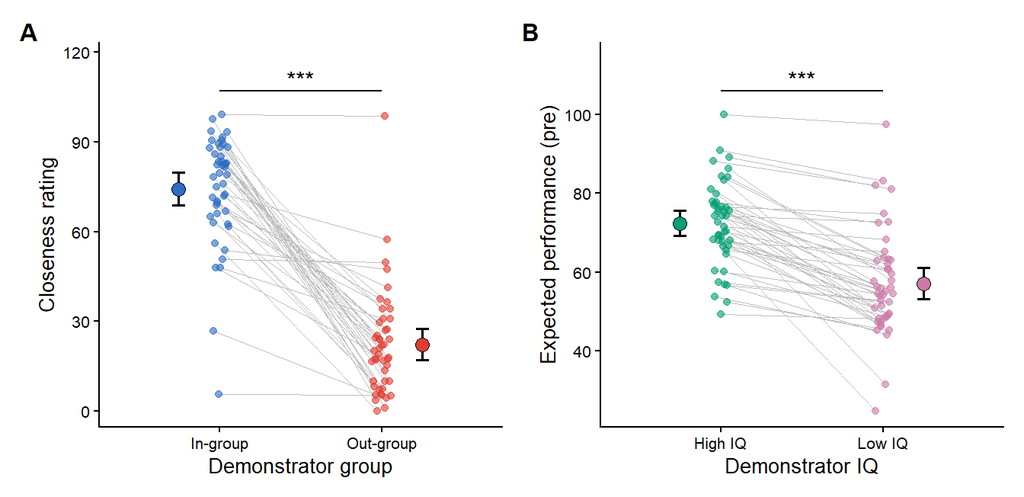

```r
fig_manipulation_checks <- (fig_closeness | fig_expectation_pre) + plot_annotation(tag_levels = "A")
fig_manipulation_checks
```

```r
ggsave(file.path(figure_dir, "manipulation_checks.png"), plot = fig_manipulation_checks,
       width = 7, height = 3.4, units = "in", dpi = 300, bg = "white")
```

## 4.4 Expected performance across the four social-prior conditions

A 2 × 2 repeated-measures ANOVA compares participant means, averaging over performance. All six pairwise comparisons use a Tukey adjustment.

```r
expectation_cells <- demonstrator_data %>%
  group_by(participant, grouping, iq) %>%
  summarise(expectation_pre = mean(perf_expectation_pre, na.rm = TRUE), .groups = "drop") %>%
  filter(is.finite(expectation_pre)) %>%
  group_by(participant) %>%
  filter(n() == 4) %>%
  ungroup()

expectation_model <- afex::aov_ez(
  id = "participant", dv = "expectation_pre", data = expectation_cells,
  within = c("grouping", "iq"))
summary(expectation_model)
```

```
##
## Univariate Type III Repeated-Measures ANOVA Assuming Sphericity
##
##             Sum Sq num Df Error SS den Df   F value    Pr(>F)
## (Intercept) 770845      1  20706.8     45 1675.1948 < 2.2e-16 ***
## grouping      5750      1   6066.5     45   42.6557 5.067e-08 ***
## iq           10766      1   5277.3     45   91.8025 1.951e-12 ***
## grouping:iq     59      1    708.8     45    3.7295   0.05977 .
## ---
## Signif. codes:  0 '***' 0.001 '**' 0.01 '*' 0.05 '.' 0.1 ' ' 1
```

```r
expectation_emm <- emmeans(expectation_model, ~ grouping * iq)
summary(expectation_emm)
```

```
##  grouping iq   emmean   SE df lower.CL upper.CL
##  in.      high   77.4 1.74 45     73.9     80.9
##  out      high   67.3 1.93 45     63.5     71.2
##  in.      low    63.2 1.86 45     59.5     67.0
##  out      low    50.9 2.37 45     46.1     55.7
##
## Confidence level used: 0.95
```

```r
summary(pairs(expectation_emm, adjust = "tukey"), infer = c(TRUE, TRUE))
```

```
##  contrast            estimate   SE df lower.CL upper.CL t.ratio p.value
##  in. high - out high    10.05 1.89 45    5.003    15.10   5.312 <0.0001
##  in. high - in. low     14.17 1.54 45   10.053    18.28   9.184 <0.0001
##  in. high - out low     26.48 2.74 45   19.179    33.78   9.677 <0.0001
##  out high - in. low      4.12 1.86 45   -0.853     9.09   2.210  0.1361
##  out high - out low     16.43 1.84 45   11.507    21.35   8.905 <0.0001
##  in. low - out low      12.31 1.72 45    7.716    16.91   7.148 <0.0001
##
## Confidence level used: 0.95
## Conf-level adjustment: tukey method for comparing a family of 4 estimates
## P value adjustment: tukey method for comparing a family of 4 estimates
```

```r
expectation_summary <- expectation_cells %>%
  group_by(grouping, iq) %>%
  summarise(n = n(), mean = mean(expectation_pre), sd = sd(expectation_pre), .groups = "drop") %>%
  mutate(ci_half = qt(0.975, n - 1) * sd / sqrt(n))

expectation_summary %>% mutate(across(where(is.numeric), ~ round(.x, 3)))
```

```
## # A tibble: 4 × 6
##   grouping iq        n  mean    sd ci_half
##   <fct>    <fct> <dbl> <dbl> <dbl>   <dbl>
## 1 in       high     46  77.4  11.8    3.50
## 2 in       low      46  63.2  12.6    3.75
## 3 out      high     46  67.3  13.1    3.88
## 4 out      low      46  50.9  16.1    4.77
```

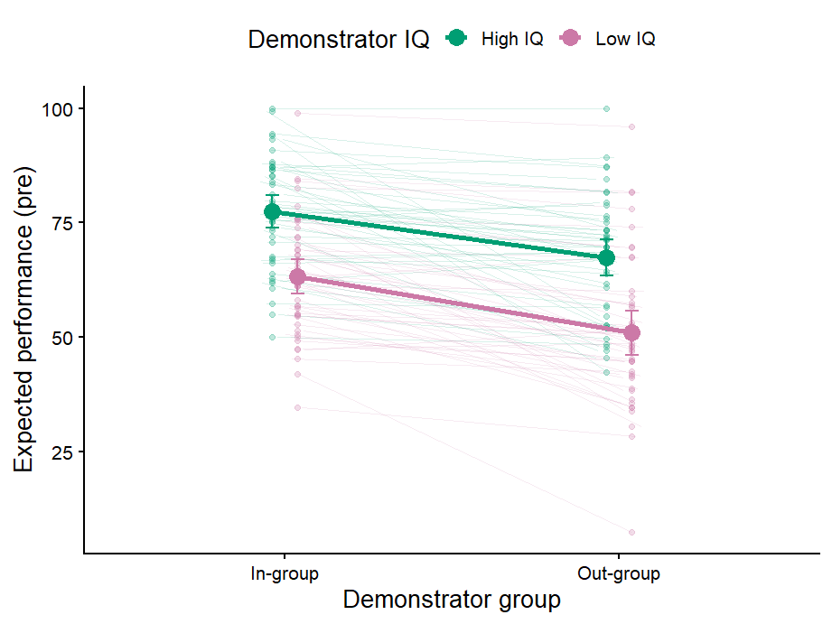

```r
fig_expectation_conditions <- ggplot(expectation_cells,
                                      aes(x = grouping, y = expectation_pre, colour = iq, group = iq)) +
  geom_line(aes(group = interaction(participant, iq)), alpha = 0.15, linewidth = 0.3,
            position = position_dodge(width = 0.15)) +
  geom_point(alpha = 0.25, size = 1, position = position_dodge(width = 0.15)) +
  geom_line(data = expectation_summary, aes(y = mean), linewidth = 0.9,
            position = position_dodge(width = 0.15)) +
  geom_errorbar(data = expectation_summary, aes(y = mean, ymin = mean - ci_half, ymax = mean + ci_half),
                width = 0.08, position = position_dodge(width = 0.15)) +
  geom_point(data = expectation_summary, aes(y = mean), size = 3,
             position = position_dodge(width = 0.15)) +
  scale_x_discrete(labels = label_grouping) +
  scale_colour_manual(values = colour_iq, labels = label_iq, name = "Demonstrator IQ") +
  labs(x = "Demonstrator group", y = "Expected performance (pre)")

fig_expectation_conditions
```

```r
ggsave(file.path(figure_dir, "expectation_conditions.png"), plot = fig_expectation_conditions,
       width = 4.8, height = 3.6, units = "in", dpi = 300, bg = "white")
```

## 4.5 Expectation update by demonstrator accuracy

Post − pre ratings are averaged within participant and demonstrator accuracy. The repeated-measures ANOVA uses participants with all accuracy levels.

```r
expectation_update_cells <- demonstrator_data %>%
  mutate(expectation_change = perf_expectation_post - perf_expectation_pre,
         demo_accuracy = factor(demo_accuracy)) %>%
  group_by(participant, demo_accuracy) %>%
  summarise(expectation_change = mean(expectation_change, na.rm = TRUE), .groups = "drop") %>%
  filter(is.finite(expectation_change))

n_accuracy_levels <- nlevels(droplevels(expectation_update_cells$demo_accuracy))
expectation_update_complete <- expectation_update_cells %>%
  group_by(participant) %>%
  filter(n() == n_accuracy_levels) %>%
  ungroup()

cat(n_distinct(expectation_update_complete$participant), "participants with all accuracy levels")
```

```
## 46 participants with all accuracy levels
```

```r
expectation_update_model <- afex::aov_ez(
  id = "participant", dv = "expectation_change", data = expectation_update_complete,
  within = "demo_accuracy")
summary(expectation_update_model)
```

```
##
## Univariate Type III Repeated-Measures ANOVA Assuming Sphericity
##
##                Sum Sq num Df Error SS den Df F value    Pr(>F)
## (Intercept)     947.1      1   4935.1     45  8.6362  0.005183 **
## demo_accuracy 14544.8      3  15493.1    135 42.2459 < 2.2e-16 ***
## ---
## Signif. codes:  0 '***' 0.001 '**' 0.01 '*' 0.05 '.' 0.1 ' ' 1
##
##
## Mauchly Tests for Sphericity
##
##               Test statistic    p-value
## demo_accuracy        0.59788 0.00042432
##
##
## Greenhouse-Geisser and Huynh-Feldt Corrections
##  for Departure from Sphericity
##
##                GG eps Pr(>F[GG])
## demo_accuracy 0.72656  1.105e-14 ***
## ---
## Signif. codes:  0 '***' 0.001 '**' 0.01 '*' 0.05 '.' 0.1 ' ' 1
##
##                  HF eps   Pr(>F[HF])
## demo_accuracy 0.7649383 2.463136e-15
```

```r
expectation_update_emm <- emmeans(expectation_update_model, ~ demo_accuracy)
summary(pairs(expectation_update_emm, adjust = "tukey"), infer = c(TRUE, TRUE))
```

```
##  contrast  estimate   SE df lower.CL upper.CL t.ratio p.value
##  X55 - X73   -14.09 1.90 45   -19.15   -9.035  -7.432 <0.0001
##  X55 - X82   -19.65 2.46 45   -26.21  -13.092  -7.992 <0.0001
##  X55 - X91   -23.41 2.90 45   -31.14  -15.687  -8.085 <0.0001
##  X73 - X82    -5.56 1.90 45   -10.62   -0.495  -2.929  0.0264
##  X73 - X91    -9.32 2.28 45   -15.39   -3.245  -4.093  0.0010
##  X82 - X91    -3.76 1.77 45    -8.48    0.957  -2.127  0.1602
##
## Confidence level used: 0.95
## Conf-level adjustment: tukey method for comparing a family of 4 estimates
## P value adjustment: tukey method for comparing a family of 4 estimates
```

```r
expectation_update_summary <- expectation_update_complete %>%
  group_by(demo_accuracy) %>%
  summarise(n = n(), mean = mean(expectation_change), sd = sd(expectation_change), .groups = "drop") %>%
  mutate(ci_half = qt(0.975, n - 1) * sd / sqrt(n))

expectation_update_summary %>% mutate(across(where(is.numeric), ~ round(.x, 3)))
```

```
## # A tibble: 4 × 5
##   demo_accuracy     n   mean    sd ci_half
##   <fct>         <dbl>  <dbl> <dbl>   <dbl>
## 1 55               46 -12.0  10.1     2.99
## 2 73               46   2.07  9.01    2.67
## 3 82               46   7.63 10.6     3.14
## 4 91               46  11.4  12.6     3.75
```

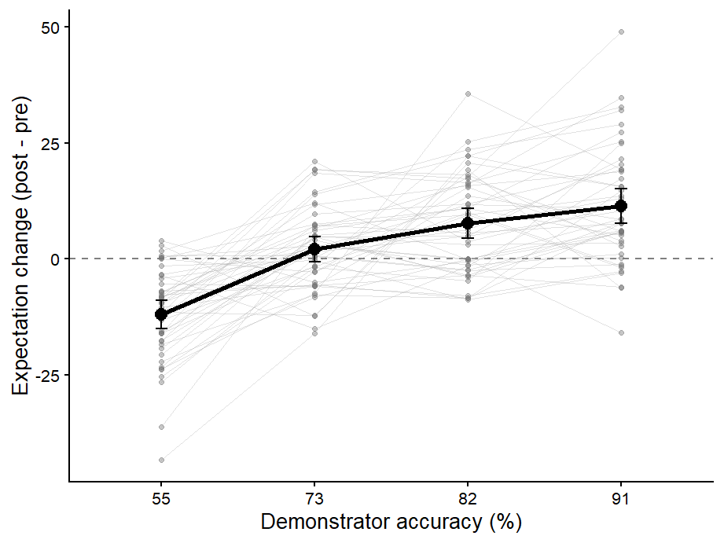

```r
fig_expectation_update <- ggplot(expectation_update_complete,
                                  aes(x = demo_accuracy, y = expectation_change)) +
  geom_hline(yintercept = 0, linetype = "dashed", colour = "grey50") +
  geom_line(aes(group = participant), colour = "grey70", alpha = 0.4, linewidth = 0.3) +
  geom_point(colour = "grey45", alpha = 0.4, size = 1) +
  geom_line(data = expectation_update_summary, aes(y = mean, group = 1), linewidth = 0.9) +
  geom_errorbar(data = expectation_update_summary,
                aes(y = mean, ymin = mean - ci_half, ymax = mean + ci_half), width = 0.08) +
  geom_point(data = expectation_update_summary, aes(y = mean), size = 2.5) +
  labs(x = "Demonstrator accuracy (%)", y = "Expectation change (post - pre)")

fig_expectation_update
```

```r
ggsave(file.path(figure_dir, "expectation_update.png"), plot = fig_expectation_update,
       width = 4.8, height = 3.6, units = "in", dpi = 300, bg = "white")
```

# 5. Choice learning model

```r
choice_model <- glmer(
  choice_correct ~ trial_c + grouping * iq * perf + trial_c * (grouping + iq + perf) +
    (1 + trial_c | participant) + (1 | demo_img),
  family    = "binomial",
  data      = trial_data,
  contrasts = list(grouping = "contr.sum", iq = "contr.sum", perf = "contr.sum"),
  control = glmerControl(optimizer = "bobyqa", optCtrl = list(maxfun = 200000)))

 summary(choice_model)
```

```
## Generalized linear mixed model fit by maximum likelihood (Laplace
##   Approximation) [glmerMod]
##  Family: binomial  ( logit )
## Formula:
## choice_correct ~ trial_c + grouping * iq * perf + trial_c * (grouping +
##     iq + perf) + (1 + trial_c | participant) + (1 | demo_img)
##    Data: trial_data
## Control: glmerControl(optimizer = "bobyqa", optCtrl = list(maxfun = 2e+05))
##
##       AIC       BIC    logLik -2*log(L)  df.resid
##    9948.4   10066.7   -4958.2    9916.4     12028
##
## Scaled residuals:
##      Min       1Q   Median       3Q      Max
## -11.6861   0.1748   0.3469   0.5009   1.3346
##
## Random effects:
##  Groups      Name        Variance Std.Dev. Corr
##  demo_img    (Intercept) 0.06229  0.2496
##  participant (Intercept) 0.70999  0.8426
##              trial_c     0.01601  0.1265   0.80
## Number of obs: 12044, groups:  demo_img, 48; participant, 46
##
## Fixed effects:
##                      Estimate Std. Error z value Pr(>|z|)
## (Intercept)          1.923548   0.133811  14.375  < 2e-16 ***
## trial_c              0.152035   0.021234   7.160 8.06e-13 ***
## grouping1            0.052684   0.026769   1.968 0.049054 *
## iq1                  0.016944   0.026648   0.636 0.524883
## perf1               -0.092921   0.026634  -3.489 0.000485 ***
## grouping1:iq1        0.003057   0.026102   0.117 0.906776
## grouping1:perf1     -0.016806   0.026155  -0.643 0.520504
## iq1:perf1            0.008642   0.026107   0.331 0.740637
## trial_c:grouping1   -0.001804   0.008177  -0.221 0.825400
## trial_c:iq1          0.004467   0.008172   0.547 0.584672
## trial_c:perf1       -0.014014   0.008185  -1.712 0.086870 .
## grouping1:iq1:perf1  0.064602   0.026138   2.472 0.013452 *
## ---
## Signif. codes:  0 '***' 0.001 '**' 0.01 '*' 0.05 '.' 0.1 ' ' 1
##
```

[output cut: 10 more lines]

```
## trial_c:iq1  0.002  0.003  0.001  0.215 -0.001 -0.001     0.005    -0.023
## tril_c:prf1 -0.009 -0.023 -0.003 -0.002  0.216  0.001    -0.002     0.006
## grpng1:q1:1  0.009  0.003  0.003 -0.002 -0.011 -0.054     0.007     0.024
##             trl_c:g1 trl_c:q1 trl_c:p1
## trial_c
## grouping1
## iq1
## perf1
## groupng1:q1
## grpng1:prf1
## iq1:perf1
## trl_c:grpn1
## trial_c:iq1 -0.001
## tril_c:prf1 -0.006    0.002
## grpng1:q1:1 -0.001   -0.002    0.000
```

```r
choice_model_fixed <- as.data.frame(coef(summary(choice_model)))
choice_model_ci    <- confint(choice_model, parm = "beta_", method = "Wald")

tibble(term       = rownames(choice_model_fixed),
       estimate   = choice_model_fixed$Estimate,
       std_error  = choice_model_fixed$`Std. Error`,
       z          = choice_model_fixed$`z value`,
       p_value    = choice_model_fixed$`Pr(>|z|)`,
       ci_low     = choice_model_ci[, 1],
       ci_high    = choice_model_ci[, 2]) %>%
  mutate(p_value = scales::pvalue(p_value, accuracy = 0.001), across(where(is.numeric), ~ round(.x, 3)))
```

```
## # A tibble: 12 × 7
##    term                estimate std_error      z p_value ci_low ci_high
##    <chr>                  <dbl>     <dbl>  <dbl> <chr>    <dbl>   <dbl>
##  1 (Intercept)            1.92      0.134 14.4   <0.001   1.66    2.19
##  2 trial_c                0.152     0.021  7.16  <0.001   0.11    0.194
##  3 grouping1              0.053     0.027  1.97  0.049    0       0.105
##  4 iq1                    0.017     0.027  0.636 0.525   -0.035   0.069
##  5 perf1                 -0.093     0.027 -3.49  <0.001  -0.145  -0.041
##  6 grouping1:iq1          0.003     0.026  0.117 0.907   -0.048   0.054
##  7 grouping1:perf1       -0.017     0.026 -0.643 0.521   -0.068   0.034
##  8 iq1:perf1              0.009     0.026  0.331 0.741   -0.043   0.06
##  9 trial_c:grouping1     -0.002     0.008 -0.221 0.825   -0.018   0.014
## 10 trial_c:iq1            0.004     0.008  0.547 0.585   -0.012   0.02
## 11 trial_c:perf1         -0.014     0.008 -1.71  0.087   -0.03    0.002
## 12 grouping1:iq1:perf1    0.065     0.026  2.47  0.013    0.013   0.116
```

# 6. Overall learning curve

```r
overall_curve_participant <- trial_data %>%
  group_by(participant, trial_num) %>%
  summarise(accuracy = mean(choice_correct, na.rm = TRUE), .groups = "drop") %>%
  filter(!is.na(accuracy)) %>%
  mutate(trial = trial_num + 1)
```

**Statistical test.** Learning is tested by the `trial_c` term of the choice learning model (section 5). Below is the model-based average slope across the eight conditions (log-odds per trial), with its odds ratio.

```r
overall_slope <- summary(emtrends(choice_model, ~ 1, var = "trial_c"), infer = c(TRUE, TRUE))
overall_slope
```

```
##  1       trial_c.trend     SE  df asymp.LCL asymp.UCL z.ratio p.value
##  overall         0.152 0.0212 Inf      0.11     0.194   7.160 <0.0001
##
## Results are averaged over the levels of: grouping, iq, perf
## Confidence level used: 0.95
```

```r
tibble(slope_log_odds = overall_slope$trial_c.trend,
       ci_low         = overall_slope$asymp.LCL,
       ci_high        = overall_slope$asymp.UCL,
       odds_ratio_per_trial = exp(overall_slope$trial_c.trend),
       p_value        = overall_slope$p.value) %>%
  mutate(p_value = scales::pvalue(p_value, accuracy = 0.001), across(where(is.numeric), ~ round(.x, 3)))
```

```
## # A tibble: 1 × 5
##   slope_log_odds ci_low ci_high odds_ratio_per_trial p_value
##            <dbl>  <dbl>   <dbl>                <dbl> <chr>
## 1          0.152   0.11   0.194                 1.16 <0.001
```

**Descriptive statistics**

```r
overall_curve_summary <- overall_curve_participant %>%
  group_by(trial) %>%
  summarise(n = n(), mean = mean(accuracy), sd = sd(accuracy), .groups = "drop") %>%
  mutate(ci_low  = mean - qt(0.975, n - 1) * sd / sqrt(n),
         ci_high = mean + qt(0.975, n - 1) * sd / sqrt(n))

overall_curve_summary %>% mutate(across(where(is.numeric), ~ round(.x, 3)))
```

```
## # A tibble: 11 × 6
##    trial     n  mean    sd ci_low ci_high
##    <dbl> <dbl> <dbl> <dbl>  <dbl>   <dbl>
##  1     1    46 0.755 0.113  0.722   0.789
##  2     2    46 0.763 0.115  0.729   0.797
##  3     3    46 0.796 0.135  0.756   0.836
##  4     4    46 0.833 0.117  0.798   0.868
##  5     5    46 0.824 0.144  0.781   0.866
##  6     6    46 0.832 0.122  0.795   0.868
##  7     7    46 0.848 0.122  0.812   0.884
##  8     8    46 0.86  0.127  0.822   0.897
##  9     9    46 0.868 0.135  0.828   0.908
## 10    10    46 0.89  0.103  0.859   0.92
## 11    11    46 0.887 0.11   0.854   0.92
```

**Figure.** Small grey points show each participant’s accuracy on each trial, jittered horizontally. The black line and ribbon show the mean and 95% CI. The dashed line is chance.

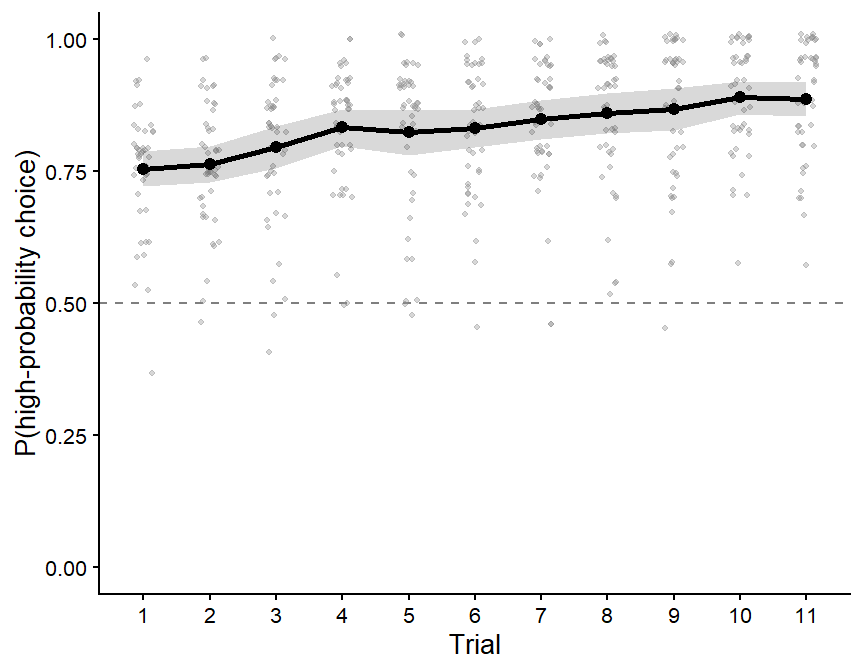

```r
fig_overall_curve <- ggplot(overall_curve_participant, aes(x = trial, y = accuracy)) +
  geom_hline(yintercept = chance_level, linetype = "dashed", colour = "grey50", linewidth = 0.4) +
  geom_point(position = position_jitter(width = 0.15, height = 0.01, seed = 1),
             colour = "grey55", alpha = 0.35, size = 0.8) +
  geom_ribbon(data = overall_curve_summary, aes(x = trial, ymin = ci_low, ymax = ci_high),
              inherit.aes = FALSE, fill = "black", alpha = 0.15) +
  geom_line(data = overall_curve_summary, aes(x = trial, y = mean), inherit.aes = FALSE, linewidth = 1) +
  geom_point(data = overall_curve_summary, aes(x = trial, y = mean), inherit.aes = FALSE, size = 1.8) +
  scale_x_continuous(breaks = sort(unique(overall_curve_participant$trial))) +
  coord_cartesian(ylim = c(0, 1)) +
  labs(x = "Trial", y = "P(high-probability choice)")

fig_overall_curve
```

```r
ggsave(file.path(figure_dir, "overall_curve.png"), plot = fig_overall_curve,
       width = 4.5, height = 3.5, units = "in", dpi = 300, bg = "white")
```

# 7. Learning curve by grouping

```r
grouping_curve_participant <- trial_data %>%
  group_by(participant, grouping, trial_num) %>%
  summarise(accuracy = mean(choice_correct, na.rm = TRUE), .groups = "drop") %>%
  filter(!is.na(accuracy)) %>%
  mutate(trial = trial_num + 1)

grouping_accuracy_wide <- trial_data %>%
  group_by(participant, grouping) %>%
  summarise(accuracy = mean(choice_correct, na.rm = TRUE), .groups = "drop") %>%
  pivot_wider(names_from = grouping, values_from = accuracy) %>%
  filter(!is.na(`in`), !is.na(out))
```

```r
coef(summary(choice_model))["grouping1", ]
```

```
##   Estimate Std. Error    z value   Pr(>|z|)
## 0.05268370 0.02676850 1.96812259 0.04905393
```

```r
grouping_accuracy_emm <- emmeans(choice_model, ~ grouping, at = list(trial_c = 0))
summary(pairs(grouping_accuracy_emm), infer = c(TRUE, TRUE))
```

```
##  contrast estimate     SE  df asymp.LCL asymp.UCL z.ratio p.value
##  in - out    0.105 0.0535 Inf  0.000437      0.21   1.968  0.0491
##
## Results are averaged over the levels of: iq, perf
## Results are given on the log odds ratio (not the response) scale.
## Confidence level used: 0.95
```

```r
summary(grouping_accuracy_emm, type = "response")     # estimated P(high-probability choice) per group
```

```
##  grouping  prob     SE  df asymp.LCL asymp.UCL
##  in       0.878 0.0146 Inf     0.847     0.904
##  out      0.867 0.0158 Inf     0.833     0.895
##
## Results are averaged over the levels of: iq, perf
## Confidence level used: 0.95
## Intervals are back-transformed from the logit scale
```

**Descriptive statistics and effect size** (participant-level mean accuracy over all trials). In-group vs. out-group is compared with a paired t test on each participant’s two mean accuracies.

```r
grouping_accuracy_t_test <- t.test(grouping_accuracy_wide$`in`, grouping_accuracy_wide$out, paired = TRUE)
grouping_accuracy_t_test
```

```
##
##  Paired t-test
##
## data:  grouping_accuracy_wide$`in` and grouping_accuracy_wide$out
## t = 1.2958, df = 45, p-value = 0.2016
## alternative hypothesis: true mean difference is not equal to 0
## 95 percent confidence interval:
##  -0.006755497  0.031130839
## sample estimates:
## mean difference
##      0.01218767
```

```r
grouping_accuracy_difference <- grouping_accuracy_wide$`in` - grouping_accuracy_wide$out
grouping_nonzero_difference  <- grouping_accuracy_difference[grouping_accuracy_difference != 0]
grouping_difference_ranks    <- rank(abs(grouping_nonzero_difference))

tibble(n             = nrow(grouping_accuracy_wide),
       mean_in       = mean(grouping_accuracy_wide$`in`),
       sem_in        = sd(grouping_accuracy_wide$`in`) / sqrt(nrow(grouping_accuracy_wide)),
       mean_out      = mean(grouping_accuracy_wide$out),
       sem_out       = sd(grouping_accuracy_wide$out) / sqrt(nrow(grouping_accuracy_wide)),
       mean_diff     = mean(grouping_accuracy_difference),
       median_diff   = median(grouping_accuracy_difference),
       V             = unname(grouping_accuracy_t_test$statistic),
       p_t           = grouping_accuracy_t_test$p.value,
       rank_biserial = (sum(grouping_difference_ranks[grouping_nonzero_difference > 0]) -
                        sum(grouping_difference_ranks[grouping_nonzero_difference < 0])) / sum(grouping_difference_ranks)) %>%
  mutate(p_t = scales::pvalue(p_t, accuracy = 0.001), across(where(is.numeric), ~ round(.x, 3)))
```

```
## # A tibble: 1 × 10
##       n mean_in sem_in mean_out sem_out mean_diff median_diff     V p_t
##   <dbl>   <dbl>  <dbl>    <dbl>   <dbl>     <dbl>       <dbl> <dbl> <chr>
## 1    46   0.839  0.015    0.826   0.016     0.012       0.018  1.30 0.202
## # ℹ 1 more variable: rank_biserial <dbl>
```

```r
grouping_curve_summary <- grouping_curve_participant %>%
  group_by(grouping, trial) %>%
  summarise(n = n(), mean = mean(accuracy), sd = sd(accuracy), .groups = "drop") %>%
  mutate(ci_low  = mean - qt(0.975, n - 1) * sd / sqrt(n),
         ci_high = mean + qt(0.975, n - 1) * sd / sqrt(n))

grouping_curve_summary %>% mutate(across(where(is.numeric), ~ round(.x, 3)))
```

```
## # A tibble: 22 × 7
##    grouping trial     n  mean    sd ci_low ci_high
##    <fct>    <dbl> <dbl> <dbl> <dbl>  <dbl>   <dbl>
##  1 in           1    46 0.767 0.146  0.724   0.81
##  2 in           2    46 0.774 0.138  0.733   0.815
##  3 in           3    46 0.811 0.145  0.768   0.854
##  4 in           4    46 0.832 0.143  0.79    0.874
##  5 in           5    46 0.829 0.152  0.783   0.874
##  6 in           6    46 0.842 0.15   0.797   0.886
##  7 in           7    46 0.847 0.146  0.804   0.89
##  8 in           8    46 0.868 0.143  0.826   0.911
##  9 in           9    46 0.861 0.167  0.812   0.911
## 10 in          10    46 0.906 0.103  0.875   0.937
## # ℹ 12 more rows
```

**Figure.**

- 1. Learning curves. Small points are participant-level accuracies per trial, shifted slightly left (in-group) or right (out-group). Lines and ribbons show the mean and 95% CI.
- 2. Participant-mean accuracy over all trials. Bars show the mean ± SEM, white points are participants, and grey lines connect the same participant’s in-group and out-group values.

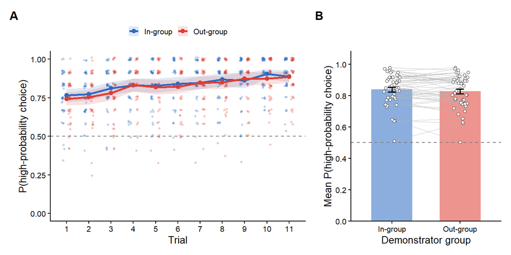

```r
grouping_curve_plot_data <- grouping_curve_participant %>%
  mutate(x_point = trial + ifelse(grouping == "in", -0.15, 0.15))

fig_grouping_curve <- ggplot(grouping_curve_plot_data, aes(x = x_point, y = accuracy, colour = grouping)) +
  geom_hline(yintercept = chance_level, linetype = "dashed", colour = "grey50", linewidth = 0.4) +
  geom_point(position = position_jitter(width = 0.06, height = 0.01, seed = 1), alpha = 0.25, size = 0.7) +
  geom_ribbon(data = grouping_curve_summary, aes(x = trial, ymin = ci_low, ymax = ci_high, fill = grouping),
              inherit.aes = FALSE, alpha = 0.15) +
  geom_line(data = grouping_curve_summary, aes(x = trial, y = mean, colour = grouping), inherit.aes = FALSE, linewidth = 1) +
  geom_point(data = grouping_curve_summary, aes(x = trial, y = mean, colour = grouping), inherit.aes = FALSE, size = 1.8) +
  scale_colour_manual(values = colour_grouping, labels = label_grouping, name = NULL) +
  scale_fill_manual(values = colour_grouping, labels = label_grouping, name = NULL) +
  scale_x_continuous(breaks = sort(unique(grouping_curve_participant$trial))) +
  coord_cartesian(ylim = c(0, 1)) +
  labs(x = "Trial", y = "P(high-probability choice)")

set.seed(1)
grouping_accuracy_jitter <- tibble(participant = grouping_accuracy_wide$participant,
                                 jitter      = runif(nrow(grouping_accuracy_wide), -0.12, 0.12))

grouping_accuracy_plot_data <- grouping_accuracy_wide %>%
  pivot_longer(c(`in`, out), names_to = "grouping", values_to = "accuracy") %>%
  left_join(grouping_accuracy_jitter, by = "participant") %>%
  mutate(grouping = factor(grouping, levels = c("in", "out")),
         x_point  = as.numeric(grouping) + jitter)

grouping_accuracy_plot_summary <- grouping_accuracy_plot_data %>%
  group_by(grouping) %>%
  summarise(n = n(), mean = mean(accuracy), sem = sd(accuracy) / sqrt(n()), .groups = "drop") %>%
  mutate(x_bar = as.numeric(grouping))

grouping_accuracy_significance <- tibble(p = grouping_accuracy_t_test$p.value,
                                  y = max(grouping_accuracy_plot_data$accuracy) + 0.04) %>%
  filter(p < .05) %>%
  mutate(label = case_when(p < .001 ~ "***", p < .01 ~ "**", TRUE ~ "*"))

fig_grouping_accuracy <- ggplot(grouping_accuracy_plot_data, aes(x = x_point, y = accuracy)) +
  geom_col(data = grouping_accuracy_plot_summary, aes(x = x_bar, y = mean, fill = grouping),
           inherit.aes = FALSE, width = 0.6, alpha = 0.55, colour = NA) +
  geom_hline(yintercept = chance_level, linetype = "dashed", colour = "grey50", linewidth = 0.4) +
  geom_line(aes(group = participant), colour = "grey70", linewidth = 0.25, alpha = 0.7) +
  geom_point(shape = 21, fill = "white", colour = "grey25", size = 1.3, stroke = 0.4) +
  geom_errorbar(data = grouping_accuracy_plot_summary, aes(x = x_bar, ymin = mean - sem, ymax = mean + sem),
                inherit.aes = FALSE, width = 0.12, linewidth = 0.7) +
  geom_segment(data = grouping_accuracy_significance, aes(x = 1, xend = 2, y = y, yend = y), inherit.aes = FALSE, linewidth = 0.6) +
  geom_text(data = grouping_accuracy_significance, aes(x = 1.5, y = y, label = label), inherit.aes = FALSE, vjust = -0.2, size = 5) +
  scale_x_continuous(breaks = 1:2, labels = label_grouping[c("in", "out")], expand = expansion(add = 0.5)) +
  scale_fill_manual(values = colour_grouping, guide = "none") +
  scale_y_continuous(breaks = seq(0, 1, 0.2)) +
  coord_cartesian(xlim = c(0.4, 2.6), ylim = c(0, 1.08), expand = FALSE) +
  labs(x = "Demonstrator group", y = "Mean P(high-probability choice)")


fig_learning_by_grouping <- (fig_grouping_curve | fig_grouping_accuracy) +
  plot_layout(widths = c(1.7, 1)) + plot_annotation(tag_levels = "A")
fig_learning_by_grouping
```

```r
ggsave(file.path(figure_dir, "learning_by_grouping.png"), plot = fig_learning_by_grouping,
       width = 7.2, height = 3.6, units = "in", dpi = 300, bg = "white")
```

# 8. Learning curve by IQ

```r
iq_curve_participant <- trial_data %>%
  group_by(participant, iq, trial_num) %>%
  summarise(accuracy = mean(choice_correct, na.rm = TRUE), .groups = "drop") %>%
  filter(!is.na(accuracy)) %>%
  mutate(trial = trial_num + 1)

iq_accuracy_wide <- trial_data %>%
  group_by(participant, iq) %>%
  summarise(accuracy = mean(choice_correct, na.rm = TRUE), .groups = "drop") %>%
  pivot_wider(names_from = iq, values_from = accuracy) %>%
  filter(!is.na(high), !is.na(low))
```

**Statistical tests.** These use the choice learning model (section 5): term `iq1`, equivalently the planned contrast high − low for accuracy at the mean trial (averaged over grouping and performance). Differences in learning rate are not tested here.

```r
coef(summary(choice_model))["iq1", ]
```

```
##   Estimate Std. Error    z value   Pr(>|z|)
## 0.01694380 0.02664803 0.63583676 0.52488283
```

```r
iq_accuracy_emm <- emmeans(choice_model, ~ iq, at = list(trial_c = 0))
summary(pairs(iq_accuracy_emm), infer = c(TRUE, TRUE))
```

```
##  contrast   estimate     SE  df asymp.LCL asymp.UCL z.ratio p.value
##  high - low   0.0339 0.0533 Inf   -0.0706     0.138   0.636  0.5249
##
## Results are averaged over the levels of: grouping, perf
## Results are given on the log odds ratio (not the response) scale.
## Confidence level used: 0.95
```

```r
summary(iq_accuracy_emm, type = "response")
```

```
##  iq    prob     SE  df asymp.LCL asymp.UCL
##  high 0.874 0.0150 Inf     0.842     0.901
##  low  0.871 0.0154 Inf     0.837     0.898
##
## Results are averaged over the levels of: grouping, perf
## Confidence level used: 0.95
## Intervals are back-transformed from the logit scale
```

**Descriptive statistics and effect size.** High vs. low IQ is compared in the same way as in section 7 (paired t test, rank-biserial correlation; positive = higher accuracy for high IQ).

```r
iq_accuracy_t_test <- t.test(iq_accuracy_wide$high, iq_accuracy_wide$low, paired = TRUE)
iq_accuracy_t_test
```

```
##
##  Paired t-test
##
## data:  iq_accuracy_wide$high and iq_accuracy_wide$low
## t = 0.21256, df = 45, p-value = 0.8326
## alternative hypothesis: true mean difference is not equal to 0
## 95 percent confidence interval:
##  -0.01999930  0.02471859
## sample estimates:
## mean difference
##     0.002359647
```

```r
iq_accuracy_difference <- iq_accuracy_wide$high - iq_accuracy_wide$low
iq_nonzero_difference  <- iq_accuracy_difference[iq_accuracy_difference != 0]
iq_difference_ranks    <- rank(abs(iq_nonzero_difference))

tibble(n             = nrow(iq_accuracy_wide),
       mean_high       = mean(iq_accuracy_wide$high),
       sem_high        = sd(iq_accuracy_wide$high) / sqrt(nrow(iq_accuracy_wide)),
       mean_low      = mean(iq_accuracy_wide$low),
       sem_low       = sd(iq_accuracy_wide$low) / sqrt(nrow(iq_accuracy_wide)),
       mean_diff     = mean(iq_accuracy_difference),
       median_diff   = median(iq_accuracy_difference),
       V             = unname(iq_accuracy_t_test$statistic),
       p_t     = iq_accuracy_t_test$p.value,
       rank_biserial = (sum(iq_difference_ranks[iq_nonzero_difference > 0]) -
                        sum(iq_difference_ranks[iq_nonzero_difference < 0])) / sum(iq_difference_ranks)) %>%
  mutate(p_t = scales::pvalue(p_t, accuracy = 0.001), across(where(is.numeric), ~ round(.x, 3)))
```

```
## # A tibble: 1 × 10
##       n mean_high sem_high mean_low sem_low mean_diff median_diff     V p_t
##   <dbl>     <dbl>    <dbl>    <dbl>   <dbl>     <dbl>       <dbl> <dbl> <chr>
## 1    46     0.834    0.015    0.831   0.016     0.002       0.003 0.213 0.833
## # ℹ 1 more variable: rank_biserial <dbl>
```

```r
iq_curve_summary <- iq_curve_participant %>%
  group_by(iq, trial) %>%
  summarise(n = n(), mean = mean(accuracy), sd = sd(accuracy), .groups = "drop") %>%
  mutate(ci_low  = mean - qt(0.975, n - 1) * sd / sqrt(n),
         ci_high = mean + qt(0.975, n - 1) * sd / sqrt(n))

iq_curve_summary %>% mutate(across(where(is.numeric), ~ round(.x, 3)))
```

```
## # A tibble: 22 × 7
##    iq    trial     n  mean    sd ci_low ci_high
##    <fct> <dbl> <dbl> <dbl> <dbl>  <dbl>   <dbl>
##  1 high      1    46 0.754 0.13   0.715   0.792
##  2 high      2    46 0.77  0.138  0.729   0.811
##  3 high      3    46 0.786 0.166  0.736   0.835
##  4 high      4    46 0.841 0.138  0.8     0.882
##  5 high      5    46 0.813 0.169  0.763   0.863
##  6 high      6    46 0.825 0.151  0.78    0.87
##  7 high      7    46 0.862 0.128  0.824   0.9
##  8 high      8    46 0.869 0.142  0.827   0.912
##  9 high      9    46 0.869 0.145  0.825   0.912
## 10 high     10    46 0.891 0.127  0.853   0.929
## # ℹ 12 more rows
```

**Figure.** The layout is the same as in section 7.

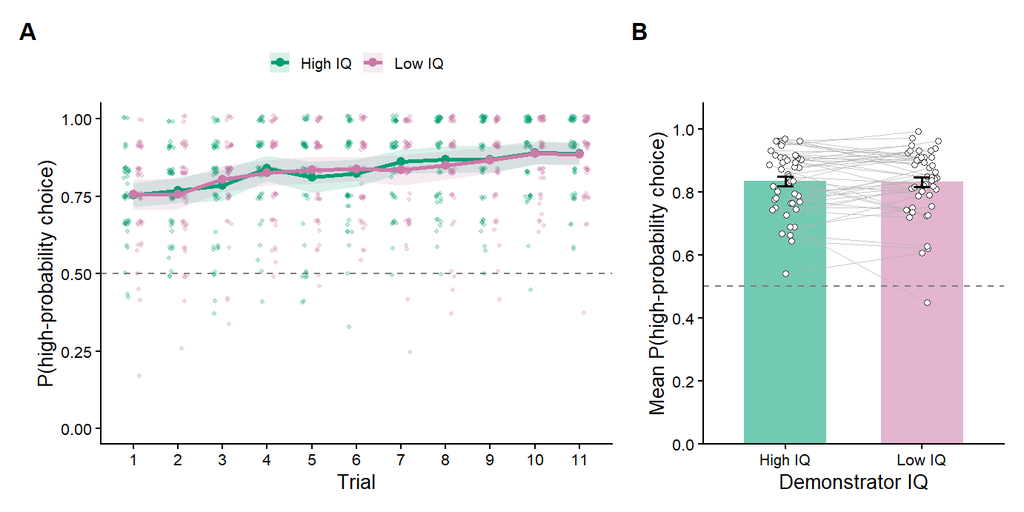

```r
iq_curve_plot_data <- iq_curve_participant %>%
  mutate(x_point = trial + ifelse(iq == "high", -0.15, 0.15))

fig_iq_curve <- ggplot(iq_curve_plot_data, aes(x = x_point, y = accuracy, colour = iq)) +
  geom_hline(yintercept = chance_level, linetype = "dashed", colour = "grey50", linewidth = 0.4) +
  geom_point(position = position_jitter(width = 0.06, height = 0.01, seed = 1), alpha = 0.25, size = 0.7) +
  geom_ribbon(data = iq_curve_summary, aes(x = trial, ymin = ci_low, ymax = ci_high, fill = iq),
              inherit.aes = FALSE, alpha = 0.15) +
  geom_line(data = iq_curve_summary, aes(x = trial, y = mean, colour = iq), inherit.aes = FALSE, linewidth = 1) +
  geom_point(data = iq_curve_summary, aes(x = trial, y = mean, colour = iq), inherit.aes = FALSE, size = 1.8) +
  scale_colour_manual(values = colour_iq, labels = label_iq, name = NULL) +
  scale_fill_manual(values = colour_iq, labels = label_iq, name = NULL) +
  scale_x_continuous(breaks = sort(unique(iq_curve_participant$trial))) +
  coord_cartesian(ylim = c(0, 1)) +
  labs(x = "Trial", y = "P(high-probability choice)")

set.seed(1)
iq_accuracy_jitter <- tibble(participant = iq_accuracy_wide$participant,
                                 jitter      = runif(nrow(iq_accuracy_wide), -0.12, 0.12))

iq_accuracy_plot_data <- iq_accuracy_wide %>%
  pivot_longer(c(high, low), names_to = "iq", values_to = "accuracy") %>%
  left_join(iq_accuracy_jitter, by = "participant") %>%
  mutate(iq = factor(iq, levels = c("high", "low")),
         x_point  = as.numeric(iq) + jitter)

iq_accuracy_plot_summary <- iq_accuracy_plot_data %>%
  group_by(iq) %>%
  summarise(n = n(), mean = mean(accuracy), sem = sd(accuracy) / sqrt(n()), .groups = "drop") %>%
  mutate(x_bar = as.numeric(iq))

iq_accuracy_significance <- tibble(p = iq_accuracy_t_test$p.value,
                                  y = max(iq_accuracy_plot_data$accuracy) + 0.04) %>%
  filter(p < .05) %>%
  mutate(label = case_when(p < .001 ~ "***", p < .01 ~ "**", TRUE ~ "*"))

fig_iq_accuracy <- ggplot(iq_accuracy_plot_data, aes(x = x_point, y = accuracy)) +
  geom_col(data = iq_accuracy_plot_summary, aes(x = x_bar, y = mean, fill = iq),
           inherit.aes = FALSE, width = 0.6, alpha = 0.55, colour = NA) +
  geom_hline(yintercept = chance_level, linetype = "dashed", colour = "grey50", linewidth = 0.4) +
  geom_line(aes(group = participant), colour = "grey70", linewidth = 0.25, alpha = 0.7) +
  geom_point(shape = 21, fill = "white", colour = "grey25", size = 1.3, stroke = 0.4) +
  geom_errorbar(data = iq_accuracy_plot_summary, aes(x = x_bar, ymin = mean - sem, ymax = mean + sem),
                inherit.aes = FALSE, width = 0.12, linewidth = 0.7) +
  geom_segment(data = iq_accuracy_significance, aes(x = 1, xend = 2, y = y, yend = y), inherit.aes = FALSE, linewidth = 0.6) +
  geom_text(data = iq_accuracy_significance, aes(x = 1.5, y = y, label = label), inherit.aes = FALSE, vjust = -0.2, size = 5) +
  scale_x_continuous(breaks = 1:2, labels = label_iq[c("high", "low")], expand = expansion(add = 0.5)) +
  scale_fill_manual(values = colour_iq, guide = "none") +
  scale_y_continuous(breaks = seq(0, 1, 0.2)) +
  coord_cartesian(xlim = c(0.4, 2.6), ylim = c(0, 1.08), expand = FALSE) +
  labs(x = "Demonstrator IQ", y = "Mean P(high-probability choice)")


fig_learning_by_iq <- (fig_iq_curve | fig_iq_accuracy) +
  plot_layout(widths = c(1.7, 1)) + plot_annotation(tag_levels = "A")
fig_learning_by_iq
```

```r
ggsave(file.path(figure_dir, "learning_by_iq.png"), plot = fig_learning_by_iq,
       width = 7.2, height = 3.6, units = "in", dpi = 300, bg = "white")
```

# 9. Learning curve by performance

```r
perf_curve_participant <- trial_data %>%
  group_by(participant, perf, trial_num) %>%
  summarise(accuracy = mean(choice_correct, na.rm = TRUE), .groups = "drop") %>%
  filter(!is.na(accuracy)) %>%
  mutate(trial = trial_num + 1)

perf_accuracy_wide <- trial_data %>%
  group_by(participant, perf) %>%
  summarise(accuracy = mean(choice_correct, na.rm = TRUE), .groups = "drop") %>%
  pivot_wider(names_from = perf, values_from = accuracy) %>%
  filter(!is.na(bad), !is.na(superb))
```

**Statistical tests.** These use the choice learning model (section 5): term `perf1`, equivalently the planned contrast bad − superb for accuracy at the mean trial (averaged over grouping and IQ). Differences in learning rate are not tested here.

```r
coef(summary(choice_model))["perf1", ]
```

```
##      Estimate    Std. Error       z value      Pr(>|z|)
## -0.0929205303  0.0266339637 -3.4887984115  0.0004851969
```

```r
perf_accuracy_emm <- emmeans(choice_model, ~ perf, at = list(trial_c = 0))
summary(pairs(perf_accuracy_emm), infer = c(TRUE, TRUE))
```

```
##  contrast     estimate     SE  df asymp.LCL asymp.UCL z.ratio p.value
##  bad - superb   -0.186 0.0533 Inf     -0.29   -0.0814  -3.489  0.0005
##
## Results are averaged over the levels of: grouping, iq
## Results are given on the log odds ratio (not the response) scale.
## Confidence level used: 0.95
```

```r
summary(perf_accuracy_emm, type = "response")
```

```
##  perf    prob     SE  df asymp.LCL asymp.UCL
##  bad    0.862 0.0162 Inf     0.827     0.891
##  superb 0.883 0.0142 Inf     0.852     0.908
##
## Results are averaged over the levels of: grouping, iq
## Confidence level used: 0.95
## Intervals are back-transformed from the logit scale
```

**Descriptive statistics and effect size.** Bad vs. superb performance is compared in the same way as in sections 7–8 (paired t test, rank-biserial correlation; positive = higher accuracy for bad performance).

```r
perf_accuracy_t_test <- t.test(perf_accuracy_wide$bad, perf_accuracy_wide$superb, paired = TRUE)
perf_accuracy_t_test
```

```
##
##  Paired t-test
##
## data:  perf_accuracy_wide$bad and perf_accuracy_wide$superb
## t = -2.0268, df = 45, p-value = 0.04864
## alternative hypothesis: true mean difference is not equal to 0
## 95 percent confidence interval:
##  -0.0405683220 -0.0001270846
## sample estimates:
## mean difference
##      -0.0203477
```

```r
perf_accuracy_difference <- perf_accuracy_wide$bad - perf_accuracy_wide$superb
perf_nonzero_difference  <- perf_accuracy_difference[perf_accuracy_difference != 0]
perf_difference_ranks    <- rank(abs(perf_nonzero_difference))

tibble(n             = nrow(perf_accuracy_wide),
       mean_bad       = mean(perf_accuracy_wide$bad),
       sem_bad        = sd(perf_accuracy_wide$bad) / sqrt(nrow(perf_accuracy_wide)),
       mean_superb      = mean(perf_accuracy_wide$superb),
       sem_superb       = sd(perf_accuracy_wide$superb) / sqrt(nrow(perf_accuracy_wide)),
       mean_diff     = mean(perf_accuracy_difference),
       median_diff   = median(perf_accuracy_difference),
       V             = unname(perf_accuracy_t_test$statistic),
       p_t      = perf_accuracy_t_test$p.value,
       rank_biserial = (sum(perf_difference_ranks[perf_nonzero_difference > 0]) -
                        sum(perf_difference_ranks[perf_nonzero_difference < 0])) / sum(perf_difference_ranks)) %>%
  mutate(p_t = scales::pvalue(p_t, accuracy = 0.001), across(where(is.numeric), ~ round(.x, 3)))
```

```
## # A tibble: 1 × 10
##       n mean_bad sem_bad mean_superb sem_superb mean_diff median_diff     V
##   <dbl>    <dbl>   <dbl>       <dbl>      <dbl>     <dbl>       <dbl> <dbl>
## 1    46    0.822   0.016       0.843      0.015     -0.02      -0.011 -2.03
## # ℹ 2 more variables: p_t <chr>, rank_biserial <dbl>
```

```r
perf_curve_summary <- perf_curve_participant %>%
  group_by(perf, trial) %>%
  summarise(n = n(), mean = mean(accuracy), sd = sd(accuracy), .groups = "drop") %>%
  mutate(ci_low  = mean - qt(0.975, n - 1) * sd / sqrt(n),
         ci_high = mean + qt(0.975, n - 1) * sd / sqrt(n))

perf_curve_summary %>% mutate(across(where(is.numeric), ~ round(.x, 3)))
```

```
## # A tibble: 22 × 7
##    perf  trial     n  mean    sd ci_low ci_high
##    <fct> <dbl> <dbl> <dbl> <dbl>  <dbl>   <dbl>
##  1 bad       1    46 0.736 0.149  0.692   0.781
##  2 bad       2    46 0.755 0.153  0.71    0.801
##  3 bad       3    46 0.801 0.165  0.752   0.85
##  4 bad       4    46 0.82  0.127  0.782   0.857
##  5 bad       5    46 0.819 0.155  0.773   0.865
##  6 bad       6    46 0.826 0.137  0.786   0.867
##  7 bad       7    46 0.85  0.139  0.808   0.891
##  8 bad       8    46 0.85  0.162  0.802   0.898
##  9 bad       9    46 0.85  0.157  0.804   0.897
## 10 bad      10    46 0.858 0.147  0.815   0.902
## # ℹ 12 more rows
```

**Figure.** The layout is the same as in section 7.

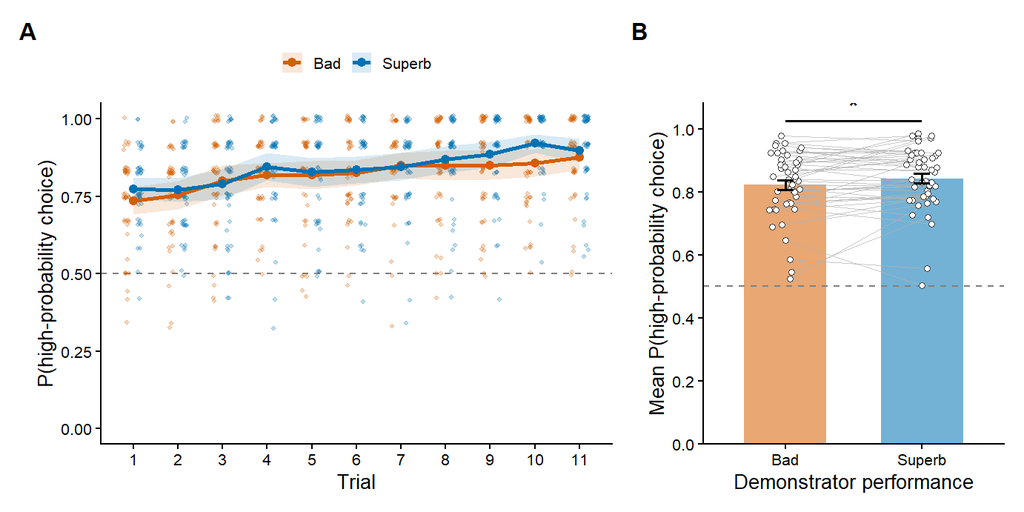

```r
perf_curve_plot_data <- perf_curve_participant %>%
  mutate(x_point = trial + ifelse(perf == "bad", -0.15, 0.15))

fig_perf_curve <- ggplot(perf_curve_plot_data, aes(x = x_point, y = accuracy, colour = perf)) +
  geom_hline(yintercept = chance_level, linetype = "dashed", colour = "grey50", linewidth = 0.4) +
  geom_point(position = position_jitter(width = 0.06, height = 0.01, seed = 1), alpha = 0.25, size = 0.7) +
  geom_ribbon(data = perf_curve_summary, aes(x = trial, ymin = ci_low, ymax = ci_high, fill = perf),
              inherit.aes = FALSE, alpha = 0.15) +
  geom_line(data = perf_curve_summary, aes(x = trial, y = mean, colour = perf), inherit.aes = FALSE, linewidth = 1) +
  geom_point(data = perf_curve_summary, aes(x = trial, y = mean, colour = perf), inherit.aes = FALSE, size = 1.8) +
  scale_colour_manual(values = colour_perf, labels = label_perf, name = NULL) +
  scale_fill_manual(values = colour_perf, labels = label_perf, name = NULL) +
  scale_x_continuous(breaks = sort(unique(perf_curve_participant$trial))) +
  coord_cartesian(ylim = c(0, 1)) +
  labs(x = "Trial", y = "P(high-probability choice)")

set.seed(1)
perf_accuracy_jitter <- tibble(participant = perf_accuracy_wide$participant,
                                 jitter      = runif(nrow(perf_accuracy_wide), -0.12, 0.12))

perf_accuracy_plot_data <- perf_accuracy_wide %>%
  pivot_longer(c(bad, superb), names_to = "perf", values_to = "accuracy") %>%
  left_join(perf_accuracy_jitter, by = "participant") %>%
  mutate(perf = factor(perf, levels = c("bad", "superb")),
         x_point  = as.numeric(perf) + jitter)

perf_accuracy_plot_summary <- perf_accuracy_plot_data %>%
  group_by(perf) %>%
  summarise(n = n(), mean = mean(accuracy), sem = sd(accuracy) / sqrt(n()), .groups = "drop") %>%
  mutate(x_bar = as.numeric(perf))

perf_accuracy_significance <- tibble(p = perf_accuracy_t_test$p.value,
                                  y = max(perf_accuracy_plot_data$accuracy) + 0.04) %>%
  filter(p < .05) %>%
  mutate(label = case_when(p < .001 ~ "***", p < .01 ~ "**", TRUE ~ "*"))

fig_perf_accuracy <- ggplot(perf_accuracy_plot_data, aes(x = x_point, y = accuracy)) +
  geom_col(data = perf_accuracy_plot_summary, aes(x = x_bar, y = mean, fill = perf),
           inherit.aes = FALSE, width = 0.6, alpha = 0.55, colour = NA) +
  geom_hline(yintercept = chance_level, linetype = "dashed", colour = "grey50", linewidth = 0.4) +
  geom_line(aes(group = participant), colour = "grey70", linewidth = 0.25, alpha = 0.7) +
  geom_point(shape = 21, fill = "white", colour = "grey25", size = 1.3, stroke = 0.4) +
  geom_errorbar(data = perf_accuracy_plot_summary, aes(x = x_bar, ymin = mean - sem, ymax = mean + sem),
                inherit.aes = FALSE, width = 0.12, linewidth = 0.7) +
  geom_segment(data = perf_accuracy_significance, aes(x = 1, xend = 2, y = y, yend = y), inherit.aes = FALSE, linewidth = 0.6) +
  geom_text(data = perf_accuracy_significance, aes(x = 1.5, y = y, label = label), inherit.aes = FALSE, vjust = -0.2, size = 5) +
  scale_x_continuous(breaks = 1:2, labels = label_perf[c("bad", "superb")], expand = expansion(add = 0.5)) +
  scale_fill_manual(values = colour_perf, guide = "none") +
  scale_y_continuous(breaks = seq(0, 1, 0.2)) +
  coord_cartesian(xlim = c(0.4, 2.6), ylim = c(0, 1.08), expand = FALSE) +
  labs(x = "Demonstrator performance", y = "Mean P(high-probability choice)")


fig_learning_by_perf <- (fig_perf_curve | fig_perf_accuracy) +
  plot_layout(widths = c(1.7, 1)) + plot_annotation(tag_levels = "A")
fig_learning_by_perf
```

```r
ggsave(file.path(figure_dir, "learning_by_perf.png"), plot = fig_learning_by_perf,
       width = 7.2, height = 3.6, units = "in", dpi = 300, bg = "white")
```

# 10. Learning curves of the four social-prior conditions by performance

## 10.1 Learning curves of the four conditions in one plot

```r
condition_curve_participant <- trial_data %>%
  group_by(participant, grouping, iq, perf, trial_num) %>%
  summarise(accuracy = mean(choice_correct, na.rm = TRUE), .groups = "drop") %>%
  filter(!is.na(accuracy)) %>%
  mutate(trial     = trial_num + 1,
         condition = factor(paste0(label_grouping[as.character(grouping)], ", ", label_iq[as.character(iq)]),
                            levels = condition_levels))

condition_curve_summary <- condition_curve_participant %>%
  group_by(condition, grouping, iq, perf, trial) %>%
  summarise(n = n(), mean = mean(accuracy), sd = sd(accuracy), .groups = "drop") %>%
  mutate(ci_low  = mean - qt(0.975, n - 1) * sd / sqrt(n),
         ci_high = mean + qt(0.975, n - 1) * sd / sqrt(n))

condition_curve_summary %>% mutate(across(where(is.numeric), ~ round(.x, 3)))
```

```
## # A tibble: 88 × 10
##    condition         grouping iq    perf  trial     n  mean    sd ci_low ci_high
##    <fct>             <fct>    <fct> <fct> <dbl> <dbl> <dbl> <dbl>  <dbl>   <dbl>
##  1 In-group, High IQ in       high  bad       1    46 0.783 0.246  0.71    0.856
##  2 In-group, High IQ in       high  bad       2    46 0.797 0.258  0.72    0.874
##  3 In-group, High IQ in       high  bad       3    46 0.83  0.245  0.757   0.902
##  4 In-group, High IQ in       high  bad       4    46 0.833 0.219  0.768   0.898
##  5 In-group, High IQ in       high  bad       5    46 0.826 0.251  0.752   0.901
##  6 In-group, High IQ in       high  bad       6    46 0.841 0.219  0.775   0.906
##  7 In-group, High IQ in       high  bad       7    46 0.841 0.23   0.772   0.909
##  8 In-group, High IQ in       high  bad       8    46 0.862 0.217  0.798   0.927
##  9 In-group, High IQ in       high  bad       9    46 0.844 0.223  0.778   0.911
## 10 In-group, High IQ in       high  bad      10    46 0.877 0.191  0.82    0.933
## # ℹ 78 more rows
```

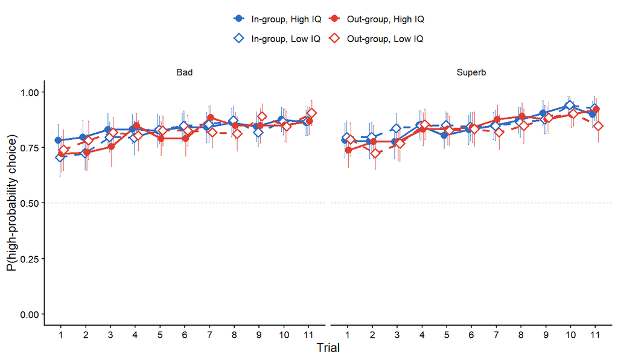

```r
fig_condition_curves_combined <- ggplot(condition_curve_summary,
                                        aes(x = trial, y = mean, colour = condition, linetype = condition, shape = condition)) +
  geom_hline(yintercept = chance_level, linetype = "dashed", colour = "grey60", linewidth = 0.3) +
  geom_errorbar(aes(ymin = ci_low, ymax = ci_high), width = 0.15, linewidth = 0.35, linetype = "solid",
                position = position_dodge(width = 0.3), show.legend = FALSE) +
  geom_line(linewidth = 0.8, position = position_dodge(width = 0.3)) +
  geom_point(size = 2.2, stroke = 1, fill = "white", position = position_dodge(width = 0.3)) +
  scale_colour_manual(values = setNames(unname(colour_grouping[c("in", "in", "out", "out")]), condition_levels), name = NULL) +
  scale_linetype_manual(values = setNames(c("solid", "dashed", "solid", "dashed"), condition_levels), name = NULL) +
  scale_shape_manual(values = setNames(c(16, 23, 16, 23), condition_levels), name = NULL) +
  scale_x_continuous(breaks = sort(unique(condition_curve_summary$trial))) +
  facet_wrap(~ perf, labeller = labeller(perf = label_perf)) +
  coord_cartesian(ylim = c(0, 1)) +
  labs(x = "Trial", y = "P(high-probability choice)") +
  guides(colour = guide_legend(nrow = 2), linetype = guide_legend(nrow = 2), shape = guide_legend(nrow = 2))

fig_condition_curves_combined
```

```r
ggsave(file.path(figure_dir, "condition_curves_combined.png"), plot = fig_condition_curves_combined,
       width = 7.2, height = 4.2, units = "in", dpi = 300, bg = "white")
```

## 10.2 Interaction plot: group x IQ (overall choice accuracy)

Each participant’s mean choice accuracy over all trials of each condition is computed first. The plot shows the mean of these participant values per condition with ± 1 SEM error bars, as in the original interaction plot. Lines connect the two groups within each IQ level. The y-axis is zoomed in on the condition means, so it does not start at 0.

```r
interaction_cells <- trial_data %>%
  group_by(participant, grouping, iq, perf) %>%
  summarise(accuracy = mean(choice_correct, na.rm = TRUE), .groups = "drop") %>%
  filter(!is.na(accuracy))

interaction_summary <- interaction_cells %>%
  group_by(grouping, iq, perf) %>%
  summarise(n = n(), mean = mean(accuracy), sd = sd(accuracy), .groups = "drop") %>%
  mutate(sem = sd / sqrt(n))

interaction_summary %>% mutate(across(where(is.numeric), ~ round(.x, 3)))
```

```
## # A tibble: 8 × 7
##   grouping iq    perf       n  mean    sd   sem
##   <fct>    <fct> <fct>  <dbl> <dbl> <dbl> <dbl>
## 1 in       high  bad       46 0.836 0.13  0.019
## 2 in       high  superb    46 0.844 0.116 0.017
## 3 in       low   bad       46 0.816 0.139 0.02
## 4 in       low   superb    46 0.858 0.108 0.016
## 5 out      high  bad       46 0.812 0.144 0.021
## 6 out      high  superb    46 0.841 0.135 0.02
## 7 out      low   bad       46 0.824 0.134 0.02
## 8 out      low   superb    46 0.827 0.163 0.024
```

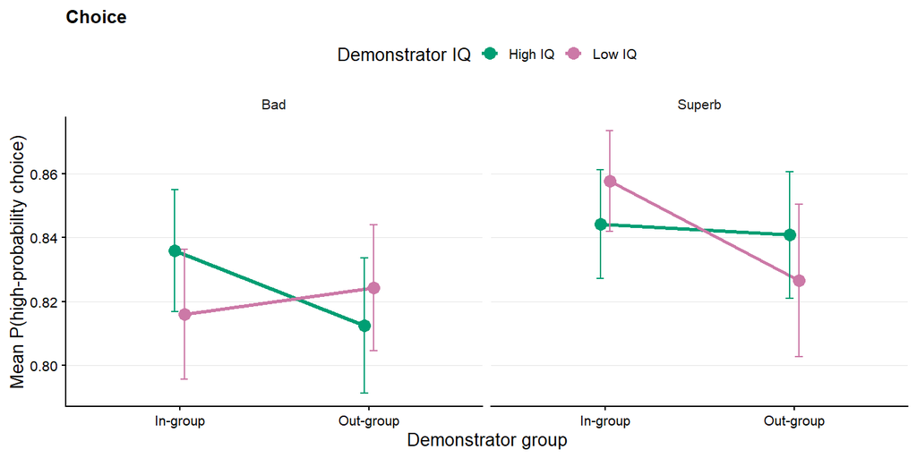

```r
fig_interaction <- ggplot(interaction_summary, aes(x = grouping, y = mean, colour = iq, group = iq)) +
  geom_line(linewidth = 0.9, position = position_dodge(width = 0.1)) +
  geom_errorbar(aes(ymin = mean - sem, ymax = mean + sem), width = 0.08, linewidth = 0.5,
                position = position_dodge(width = 0.1)) +
  geom_point(size = 3, position = position_dodge(width = 0.1)) +
  scale_x_discrete(labels = label_grouping) +
  scale_colour_manual(values = colour_iq, labels = label_iq, name = "Demonstrator IQ") +
  facet_wrap(~ perf, labeller = labeller(perf = label_perf)) +
  labs(x = "Demonstrator group", y = "Mean P(high-probability choice)", title = "Choice") +
  theme(panel.grid.major.y = element_line(colour = "grey90", linewidth = 0.3))

fig_interaction
```

```r
ggsave(file.path(figure_dir, "interaction.png"), plot = fig_interaction,
       width = 7.2, height = 3.6, units = "in", dpi = 300, bg = "white")
```

## 10.3 Choice accuracy and learning slopes within performance

Accuracy contrasts are evaluated at trial 6; slope contrasts are in log-odds per trial. Pairwise comparisons among the four social-prior conditions are Tukey-adjusted within each performance level.

```r
choice_condition_emm <- emmeans(choice_model, ~ grouping * iq | perf, at = list(trial_c = 0))
summary(choice_condition_emm, type = "response")
```

```
## perf = bad:
##  grouping iq    prob     SE  df asymp.LCL asymp.UCL
##  in       high 0.877 0.0164 Inf     0.841     0.905
##  out      high 0.852 0.0188 Inf     0.812     0.885
##  in       low  0.855 0.0186 Inf     0.815     0.888
##  out      low  0.863 0.0178 Inf     0.824     0.894
##
## perf = superb:
##  grouping iq    prob     SE  df asymp.LCL asymp.UCL
##  in       high 0.884 0.0156 Inf     0.850     0.911
##  out      high 0.883 0.0158 Inf     0.848     0.910
##  in       low  0.895 0.0144 Inf     0.863     0.920
##  out      low  0.867 0.0173 Inf     0.830     0.898
##
## Confidence level used: 0.95
## Intervals are back-transformed from the logit scale
```

```r
summary(pairs(choice_condition_emm, adjust = "tukey"), infer = c(TRUE, TRUE))
```

```
## perf = bad:
##  contrast           estimate    SE  df asymp.LCL asymp.UCL z.ratio p.value
##  in high - out high   0.2071 0.103 Inf   -0.0576     0.472   2.010  0.1842
##  in high - in low     0.1865 0.104 Inf   -0.0800     0.453   1.798  0.2744
##  in high - out low    0.1229 0.105 Inf   -0.1458     0.392   1.175  0.6426
##  out high - in low   -0.0206 0.102 Inf   -0.2815     0.240  -0.203  0.9971
##  out high - out low  -0.0841 0.101 Inf   -0.3433     0.175  -0.834  0.8383
##  in low - out low    -0.0636 0.102 Inf   -0.3251     0.198  -0.624  0.9243
##
## perf = superb:
##  contrast           estimate    SE  df asymp.LCL asymp.UCL z.ratio p.value
##  in high - out high   0.0159 0.108 Inf   -0.2615     0.293   0.147  0.9989
##  in high - in low    -0.1065 0.109 Inf   -0.3869     0.174  -0.975  0.7635
##  in high - out low    0.1556 0.106 Inf   -0.1170     0.428   1.466  0.4579
##  out high - in low   -0.1224 0.110 Inf   -0.4057     0.161  -1.110  0.6835
##  out high - out low   0.1397 0.106 Inf   -0.1327     0.412   1.318  0.5517
##  in low - out low     0.2621 0.108 Inf   -0.0147     0.539   2.432  0.0711
##
## Results are given on the log odds ratio (not the response) scale.
## Confidence level used: 0.95
## Conf-level adjustment: tukey method for comparing a family of 4 estimates
## P value adjustment: tukey method for comparing a family of 4 estimates
```

```r
choice_condition_slopes <- emtrends(choice_model, ~ grouping * iq | perf, var = "trial_c")
summary(choice_condition_slopes, infer = c(TRUE, TRUE))
```

```
## perf = bad:
##  grouping iq   trial_c.trend     SE  df asymp.LCL asymp.UCL z.ratio p.value
##  in       high         0.141 0.0255 Inf    0.0908     0.191   5.526 <0.0001
##  out      high         0.144 0.0253 Inf    0.0947     0.194   5.697 <0.0001
##  in       low          0.132 0.0254 Inf    0.0819     0.182   5.185 <0.0001
##  out      low          0.135 0.0253 Inf    0.0858     0.185   5.356 <0.0001
##
## perf = superb:
##  grouping iq   trial_c.trend     SE  df asymp.LCL asymp.UCL z.ratio p.value
##  in       high         0.169 0.0258 Inf    0.1182     0.219   6.541 <0.0001
##  out      high         0.172 0.0256 Inf    0.1221     0.222   6.732 <0.0001
##  in       low          0.160 0.0258 Inf    0.1093     0.210   6.201 <0.0001
##  out      low          0.163 0.0256 Inf    0.1133     0.213   6.391 <0.0001
##
## Confidence level used: 0.95
```

```r
summary(pairs(choice_condition_slopes, adjust = "tukey"), infer = c(TRUE, TRUE))
```

```
## perf = bad:
##  contrast           estimate     SE  df asymp.LCL asymp.UCL z.ratio p.value
##  in high - out high -0.00361 0.0164 Inf   -0.0456    0.0384  -0.221  0.9962
##  in high - in low    0.00893 0.0163 Inf   -0.0331    0.0509   0.547  0.9475
##  in high - out low   0.00533 0.0231 Inf   -0.0540    0.0647   0.230  0.9957
##  out high - in low   0.01254 0.0231 Inf   -0.0469    0.0720   0.542  0.9487
##  out high - out low  0.00893 0.0163 Inf   -0.0331    0.0509   0.547  0.9475
##  in low - out low   -0.00361 0.0164 Inf   -0.0456    0.0384  -0.221  0.9962
##
## perf = superb:
##  contrast           estimate     SE  df asymp.LCL asymp.UCL z.ratio p.value
##  in high - out high -0.00361 0.0164 Inf   -0.0456    0.0384  -0.221  0.9962
##  in high - in low    0.00893 0.0163 Inf   -0.0331    0.0509   0.547  0.9475
##  in high - out low   0.00533 0.0231 Inf   -0.0540    0.0647   0.230  0.9957
##  out high - in low   0.01254 0.0231 Inf   -0.0469    0.0720   0.542  0.9487
##  out high - out low  0.00893 0.0163 Inf   -0.0331    0.0509   0.547  0.9475
##  in low - out low   -0.00361 0.0164 Inf   -0.0456    0.0384  -0.221  0.9962
##
## Confidence level used: 0.95
## Conf-level adjustment: tukey method for comparing a family of 4 estimates
## P value adjustment: tukey method for comparing a family of 4 estimates
```

```r
choice_perf_slopes <- emtrends(choice_model, ~ perf, var = "trial_c")
summary(choice_perf_slopes, infer = c(TRUE, TRUE))
```

```
##  perf   trial_c.trend     SE  df asymp.LCL asymp.UCL z.ratio p.value
##  bad            0.138 0.0226 Inf    0.0938     0.182   6.113 <0.0001
##  superb         0.166 0.0229 Inf    0.1211     0.211   7.241 <0.0001
##
## Results are averaged over the levels of: grouping, iq
## Confidence level used: 0.95
```

```r
summary(pairs(choice_perf_slopes), infer = c(TRUE, TRUE))
```

```
##  contrast     estimate     SE  df asymp.LCL asymp.UCL z.ratio p.value
##  bad - superb   -0.028 0.0164 Inf   -0.0601   0.00406  -1.712  0.0869
##
## Results are averaged over the levels of: grouping, iq
## Confidence level used: 0.95
```

# 11. Prediction model and figures

Prediction accuracy is whether the participant correctly predicted the demonstrator’s choice. The model includes trial × grouping × IQ × performance, with participant and demonstrator-image random intercepts.

```r
prediction_model <- glmer(
  pred_correct ~ trial_c * grouping * iq * perf +
    (1 | participant) + (1 | demo_img),
  family = "binomial", data = prediction_trial_data,
  contrasts = list(grouping = "contr.sum", iq = "contr.sum", perf = "contr.sum"),
  control = glmerControl(optimizer = "bobyqa", optCtrl = list(maxfun = 200000)))

summary(prediction_model)
```

```
## Generalized linear mixed model fit by maximum likelihood (Laplace
##   Approximation) [glmerMod]
##  Family: binomial  ( logit )
## Formula: pred_correct ~ trial_c * grouping * iq * perf + (1 | participant) +
##     (1 | demo_img)
##    Data: prediction_trial_data
## Control: glmerControl(optimizer = "bobyqa", optCtrl = list(maxfun = 2e+05))
##
##       AIC       BIC    logLik -2*log(L)  df.resid
##   15069.9   15203.1   -7517.0   15033.9     12077
##
## Scaled residuals:
##     Min      1Q  Median      3Q     Max
## -3.2645 -1.0203  0.4483  0.8843  1.3364
##
## Random effects:
##  Groups      Name        Variance Std.Dev.
##  demo_img    (Intercept) 0.004435 0.0666
##  participant (Intercept) 0.022639 0.1505
## Number of obs: 12095, groups:  demo_img, 48; participant, 46
##
## Fixed effects:
##                               Estimate Std. Error z value Pr(>|z|)
## (Intercept)                  0.5470220  0.0315602  17.333   <2e-16 ***
## trial_c                      0.1359918  0.0065023  20.915   <2e-16 ***
## grouping1                    0.0131807  0.0203493   0.648   0.5172
## iq1                          0.0518679  0.0203648   2.547   0.0109 *
## perf1                       -0.4496859  0.0203550 -22.092   <2e-16 ***
## trial_c:grouping1           -0.0013964  0.0064976  -0.215   0.8298
## trial_c:iq1                  0.0165498  0.0064977   2.547   0.0109 *
## grouping1:iq1               -0.0119614  0.0203462  -0.588   0.5566
## trial_c:perf1               -0.0915781  0.0064994 -14.090   <2e-16 ***
## grouping1:perf1              0.0003967  0.0203228   0.020   0.9844
## iq1:perf1                   -0.0060606  0.0203294  -0.298   0.7656
## trial_c:grouping1:iq1       -0.0056199  0.0064976  -0.865   0.3871
## trial_c:grouping1:perf1     -0.0019363  0.0064976  -0.298   0.7657
## trial_c:iq1:perf1            0.0054682  0.0064977   0.842   0.4000
## grouping1:iq1:perf1          0.0301273  0.0203477   1.481   0.1387
## trial_c:grouping1:iq1:perf1 -0.0044829  0.0064976  -0.690   0.4902
## ---
## Signif. codes:  0 '***' 0.001 '**' 0.01 '*' 0.05 '.' 0.1 ' ' 1
```

```r
isSingular(prediction_model)
```

```
## [1] FALSE
```

```r
joint_tests(prediction_model, at = list(trial_c = c(-1, 1)))
```

```
##  model term               df1 df2 F.ratio   Chisq p.value
##  trial_c                    1 Inf 437.416 437.416 <0.0001
##  grouping                   1 Inf   0.420   0.420  0.5172
##  iq                         1 Inf   6.487   6.487  0.0109
##  perf                       1 Inf 488.066 488.066 <0.0001
##  trial_c:grouping           1 Inf   0.046   0.046  0.8298
##  trial_c:iq                 1 Inf   6.487   6.487  0.0109
##  trial_c:perf               1 Inf 198.532 198.532 <0.0001
##  grouping:iq                1 Inf   0.346   0.346  0.5566
##  grouping:perf              1 Inf   0.000   0.000  0.9844
##  iq:perf                    1 Inf   0.089   0.089  0.7656
##  trial_c:grouping:iq        1 Inf   0.748   0.748  0.3871
##  trial_c:grouping:perf      1 Inf   0.089   0.089  0.7657
##  trial_c:iq:perf            1 Inf   0.708   0.708  0.4000
##  grouping:iq:perf           1 Inf   2.192   2.192  0.1387
##  trial_c:grouping:iq:perf   1 Inf   0.476   0.476  0.4902
```

```r
prediction_model_fixed <- as.data.frame(coef(summary(prediction_model)))
prediction_model_ci <- confint(prediction_model, parm = "beta_", method = "Wald")

tibble(term = rownames(prediction_model_fixed),
       estimate = prediction_model_fixed$Estimate,
       std_error = prediction_model_fixed$`Std. Error`,
       z = prediction_model_fixed$`z value`,
       p_value = prediction_model_fixed$`Pr(>|z|)`,
       ci_low = prediction_model_ci[, 1],
       ci_high = prediction_model_ci[, 2]) %>%
  mutate(p_value = scales::pvalue(p_value, accuracy = 0.001),
         across(where(is.numeric), ~ round(.x, 3)))
```

```
## # A tibble: 16 × 7
##    term                        estimate std_error       z p_value ci_low ci_high
##    <chr>                          <dbl>     <dbl>   <dbl> <chr>    <dbl>   <dbl>
##  1 (Intercept)                    0.547     0.032  17.3   <0.001   0.485   0.609
##  2 trial_c                        0.136     0.007  20.9   <0.001   0.123   0.149
##  3 grouping1                      0.013     0.02    0.648 0.517   -0.027   0.053
##  4 iq1                            0.052     0.02    2.55  0.011    0.012   0.092
##  5 perf1                         -0.45      0.02  -22.1   <0.001  -0.49   -0.41
##  6 trial_c:grouping1             -0.001     0.006  -0.215 0.830   -0.014   0.011
##  7 trial_c:iq1                    0.017     0.006   2.55  0.011    0.004   0.029
##  8 grouping1:iq1                 -0.012     0.02   -0.588 0.557   -0.052   0.028
##  9 trial_c:perf1                 -0.092     0.006 -14.1   <0.001  -0.104  -0.079
## 10 grouping1:perf1                0         0.02    0.02  0.984   -0.039   0.04
## 11 iq1:perf1                     -0.006     0.02   -0.298 0.766   -0.046   0.034
## 12 trial_c:grouping1:iq1         -0.006     0.006  -0.865 0.387   -0.018   0.007
## 13 trial_c:grouping1:perf1       -0.002     0.006  -0.298 0.766   -0.015   0.011
## 14 trial_c:iq1:perf1              0.005     0.006   0.842 0.400   -0.007   0.018
## 15 grouping1:iq1:perf1            0.03      0.02    1.48  0.139   -0.01    0.07
## 16 trial_c:grouping1:iq1:perf1   -0.004     0.006  -0.69  0.490   -0.017   0.008
```

## 11.1 Prediction accuracy and slopes by performance

```r
prediction_perf_emm <- emmeans(prediction_model, ~ perf, at = list(trial_c = 0))
summary(prediction_perf_emm, type = "response")
```

```
##  perf    prob      SE  df asymp.LCL asymp.UCL
##  bad    0.524 0.00885 Inf     0.507     0.542
##  superb 0.730 0.00778 Inf     0.715     0.745
##
## Results are averaged over the levels of: grouping, iq
## Confidence level used: 0.95
## Intervals are back-transformed from the logit scale
```

```r
summary(pairs(prediction_perf_emm), infer = c(TRUE, TRUE))
```

```
##  contrast     estimate     SE  df asymp.LCL asymp.UCL z.ratio p.value
##  bad - superb   -0.899 0.0407 Inf    -0.979     -0.82 -22.092 <0.0001
##
## Results are averaged over the levels of: grouping, iq
## Results are given on the log odds ratio (not the response) scale.
## Confidence level used: 0.95
```

```r
prediction_perf_slopes <- emtrends(prediction_model, ~ perf, var = "trial_c")
summary(prediction_perf_slopes, infer = c(TRUE, TRUE))
```

```
##  perf   trial_c.trend      SE  df asymp.LCL asymp.UCL z.ratio p.value
##  bad           0.0444 0.00822 Inf    0.0283    0.0605   5.401 <0.0001
##  superb        0.2276 0.01010 Inf    0.2078    0.2473  22.596 <0.0001
##
## Results are averaged over the levels of: grouping, iq
## Confidence level used: 0.95
```

```r
summary(pairs(prediction_perf_slopes), infer = c(TRUE, TRUE))
```

```
##  contrast     estimate    SE  df asymp.LCL asymp.UCL z.ratio p.value
##  bad - superb   -0.183 0.013 Inf    -0.209    -0.158 -14.090 <0.0001
##
## Results are averaged over the levels of: grouping, iq
## Confidence level used: 0.95
```

```r
prediction_condition_emm <- emmeans(prediction_model, ~ grouping * iq | perf,
                                    at = list(trial_c = 0))
summary(prediction_condition_emm, type = "response")
```

```
## perf = bad:
##  grouping iq    prob     SE  df asymp.LCL asymp.UCL
##  in       high 0.544 0.0143 Inf     0.516     0.571
##  out      high 0.528 0.0143 Inf     0.500     0.556
##  in       low  0.512 0.0143 Inf     0.484     0.540
##  out      low  0.514 0.0143 Inf     0.486     0.542
##
## perf = superb:
##  grouping iq    prob     SE  df asymp.LCL asymp.UCL
##  in       high 0.736 0.0132 Inf     0.709     0.761
##  out      high 0.747 0.0130 Inf     0.721     0.772
##  in       low  0.730 0.0131 Inf     0.703     0.755
##  out      low  0.708 0.0134 Inf     0.681     0.733
##
## Confidence level used: 0.95
## Intervals are back-transformed from the logit scale
```

```r
summary(pairs(prediction_condition_emm, adjust = "tukey"), infer = c(TRUE, TRUE))
```

```
## perf = bad:
##  contrast           estimate     SE  df asymp.LCL asymp.UCL z.ratio p.value
##  in high - out high  0.06349 0.0738 Inf   -0.1262     0.253   0.860  0.8255
##  in high - in low    0.12795 0.0737 Inf   -0.0614     0.317   1.736  0.3049
##  in high - out low   0.11877 0.0736 Inf   -0.0704     0.308   1.613  0.3713
##  out high - in low   0.06446 0.0737 Inf   -0.1249     0.254   0.875  0.8181
##  out high - out low  0.05528 0.0737 Inf   -0.1340     0.245   0.750  0.8766
##  in low - out low   -0.00918 0.0734 Inf   -0.1978     0.179  -0.125  0.9993
##
## perf = superb:
##  contrast           estimate     SE  df asymp.LCL asymp.UCL z.ratio p.value
##  in high - out high -0.05861 0.0902 Inf   -0.2904     0.173  -0.650  0.9157
##  in high - in low    0.03168 0.0886 Inf   -0.1960     0.259   0.357  0.9844
##  in high - out low   0.14142 0.0874 Inf   -0.0831     0.366   1.618  0.3682
##  out high - in low   0.09029 0.0894 Inf   -0.1393     0.320   1.010  0.7435
##  out high - out low  0.20003 0.0882 Inf   -0.0266     0.427   2.268  0.1056
##  in low - out low    0.10975 0.0866 Inf   -0.1128     0.332   1.267  0.5839
##
## Results are given on the log odds ratio (not the response) scale.
## Confidence level used: 0.95
## Conf-level adjustment: tukey method for comparing a family of 4 estimates
## P value adjustment: tukey method for comparing a family of 4 estimates
```

```r
prediction_condition_slopes <- emtrends(prediction_model, ~ grouping * iq | perf,
                                        var = "trial_c")
summary(prediction_condition_slopes, infer = c(TRUE, TRUE))
```

```
## perf = bad:
##  grouping iq   trial_c.trend     SE  df asymp.LCL asymp.UCL z.ratio p.value
##  in       high        0.0530 0.0165 Inf   0.02067    0.0853   3.213  0.0013
##  out      high        0.0799 0.0166 Inf   0.04739    0.1123   4.820 <0.0001
##  in       low         0.0292 0.0164 Inf  -0.00294    0.0613   1.781  0.0750
##  out      low         0.0156 0.0163 Inf  -0.01639    0.0476   0.957  0.3388
##
## perf = superb:
##  grouping iq   trial_c.trend     SE  df asymp.LCL asymp.UCL z.ratio p.value
##  in       high        0.2381 0.0204 Inf   0.19808    0.2780  11.673 <0.0001
##  out      high        0.2392 0.0206 Inf   0.19882    0.2797  11.599 <0.0001
##  in       low         0.2182 0.0200 Inf   0.17900    0.2573  10.919 <0.0001
##  out      low         0.2148 0.0195 Inf   0.17659    0.2530  11.014 <0.0001
##
## Confidence level used: 0.95
```

## 11.2 Prediction curves by grouping, IQ and performance

Means and 95% CIs are calculated across participant-level accuracies.

```r
prediction_grouping_participant <- prediction_trial_data %>%
  group_by(participant, grouping, trial_num) %>%
  summarise(accuracy = mean(pred_correct, na.rm = TRUE), .groups = "drop") %>%
  filter(is.finite(accuracy)) %>%
  mutate(trial = trial_num + 1)

prediction_grouping_summary <- prediction_grouping_participant %>%
  group_by(grouping, trial) %>%
  summarise(n = n(), mean = mean(accuracy), sd = sd(accuracy), .groups = "drop") %>%
  mutate(ci_low = mean - qt(0.975, n - 1) * sd / sqrt(n),
         ci_high = mean + qt(0.975, n - 1) * sd / sqrt(n))

fig_prediction_grouping <- ggplot(prediction_grouping_summary,
                              aes(x = trial, y = mean, colour = grouping, fill = grouping)) +
  geom_hline(yintercept = chance_level, linetype = "dashed", colour = "grey50", linewidth = 0.4) +
  geom_ribbon(aes(ymin = ci_low, ymax = ci_high), alpha = 0.15, colour = NA) +
  geom_line(linewidth = 0.9) +
  geom_point(size = 1.8) +
  scale_colour_manual(values = colour_grouping, labels = label_grouping, name = NULL) +
  scale_fill_manual(values = colour_grouping, labels = label_grouping, name = NULL) +
  scale_x_continuous(breaks = 1:11) +
  coord_cartesian(ylim = c(0, 1)) +
  labs(x = "Trial", y = "P(correct prediction)")
```

```r
prediction_iq_participant <- prediction_trial_data %>%
  group_by(participant, iq, trial_num) %>%
  summarise(accuracy = mean(pred_correct, na.rm = TRUE), .groups = "drop") %>%
  filter(is.finite(accuracy)) %>%
  mutate(trial = trial_num + 1)

prediction_iq_summary <- prediction_iq_participant %>%
  group_by(iq, trial) %>%
  summarise(n = n(), mean = mean(accuracy), sd = sd(accuracy), .groups = "drop") %>%
  mutate(ci_low = mean - qt(0.975, n - 1) * sd / sqrt(n),
         ci_high = mean + qt(0.975, n - 1) * sd / sqrt(n))

fig_prediction_iq <- ggplot(prediction_iq_summary,
                              aes(x = trial, y = mean, colour = iq, fill = iq)) +
  geom_hline(yintercept = chance_level, linetype = "dashed", colour = "grey50", linewidth = 0.4) +
  geom_ribbon(aes(ymin = ci_low, ymax = ci_high), alpha = 0.15, colour = NA) +
  geom_line(linewidth = 0.9) +
  geom_point(size = 1.8) +
  scale_colour_manual(values = colour_iq, labels = label_iq, name = NULL) +
  scale_fill_manual(values = colour_iq, labels = label_iq, name = NULL) +
  scale_x_continuous(breaks = 1:11) +
  coord_cartesian(ylim = c(0, 1)) +
  labs(x = "Trial", y = "P(correct prediction)")
```

```r
prediction_perf_participant <- prediction_trial_data %>%
  group_by(participant, perf, trial_num) %>%
  summarise(accuracy = mean(pred_correct, na.rm = TRUE), .groups = "drop") %>%
  filter(is.finite(accuracy)) %>%
  mutate(trial = trial_num + 1)

prediction_perf_summary <- prediction_perf_participant %>%
  group_by(perf, trial) %>%
  summarise(n = n(), mean = mean(accuracy), sd = sd(accuracy), .groups = "drop") %>%
  mutate(ci_low = mean - qt(0.975, n - 1) * sd / sqrt(n),
         ci_high = mean + qt(0.975, n - 1) * sd / sqrt(n))

fig_prediction_perf <- ggplot(prediction_perf_summary,
                              aes(x = trial, y = mean, colour = perf, fill = perf)) +
  geom_hline(yintercept = chance_level, linetype = "dashed", colour = "grey50", linewidth = 0.4) +
  geom_ribbon(aes(ymin = ci_low, ymax = ci_high), alpha = 0.15, colour = NA) +
  geom_line(linewidth = 0.9) +
  geom_point(size = 1.8) +
  scale_colour_manual(values = colour_perf, labels = label_perf, name = NULL) +
  scale_fill_manual(values = colour_perf, labels = label_perf, name = NULL) +
  scale_x_continuous(breaks = 1:11) +
  coord_cartesian(ylim = c(0, 1)) +
  labs(x = "Trial", y = "P(correct prediction)")
```

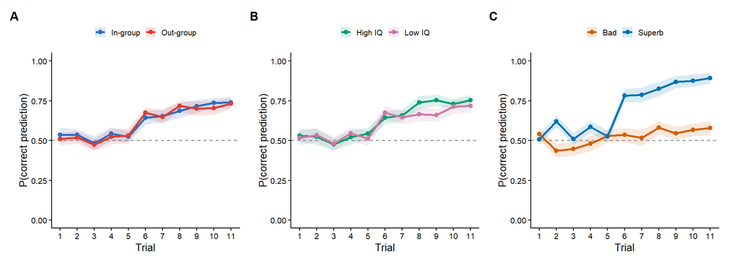

```r
fig_prediction_marginal <- (fig_prediction_grouping | fig_prediction_iq | fig_prediction_perf) +
  plot_annotation(tag_levels = "A")
fig_prediction_marginal
```

```r
ggsave(file.path(figure_dir, "prediction_marginal.png"), plot = fig_prediction_marginal,
       width = 10, height = 3.6, units = "in", dpi = 300, bg = "white")
```

## 11.3 Prediction curves of the four social-prior conditions by performance

```r
prediction_condition_curve_participant <- prediction_trial_data %>%
  group_by(participant, grouping, iq, perf, trial_num) %>%
  summarise(accuracy = mean(pred_correct, na.rm = TRUE), .groups = "drop") %>%
  filter(!is.na(accuracy)) %>%
  mutate(trial     = trial_num + 1,
         condition = factor(paste0(label_grouping[as.character(grouping)], ", ", label_iq[as.character(iq)]),
                            levels = condition_levels))

prediction_condition_curve_summary <- prediction_condition_curve_participant %>%
  group_by(condition, grouping, iq, perf, trial) %>%
  summarise(n = n(), mean = mean(accuracy), sd = sd(accuracy), .groups = "drop") %>%
  mutate(ci_low  = mean - qt(0.975, n - 1) * sd / sqrt(n),
         ci_high = mean + qt(0.975, n - 1) * sd / sqrt(n))

prediction_condition_curve_summary %>% mutate(across(where(is.numeric), ~ round(.x, 3)))
```

```
## # A tibble: 88 × 10
##    condition         grouping iq    perf  trial     n  mean    sd ci_low ci_high
##    <fct>             <fct>    <fct> <fct> <dbl> <dbl> <dbl> <dbl>  <dbl>   <dbl>
##  1 In-group, High IQ in       high  bad       1    46 0.594 0.289  0.508   0.68
##  2 In-group, High IQ in       high  bad       2    46 0.417 0.235  0.347   0.486
##  3 In-group, High IQ in       high  bad       3    46 0.399 0.303  0.309   0.489
##  4 In-group, High IQ in       high  bad       4    46 0.5   0.279  0.417   0.583
##  5 In-group, High IQ in       high  bad       5    46 0.572 0.26   0.495   0.65
##  6 In-group, High IQ in       high  bad       6    46 0.543 0.284  0.459   0.628
##  7 In-group, High IQ in       high  bad       7    46 0.58  0.285  0.495   0.664
##  8 In-group, High IQ in       high  bad       8    46 0.623 0.319  0.528   0.718
##  9 In-group, High IQ in       high  bad       9    46 0.572 0.278  0.49    0.655
## 10 In-group, High IQ in       high  bad      10    46 0.601 0.194  0.544   0.659
## # ℹ 78 more rows
```

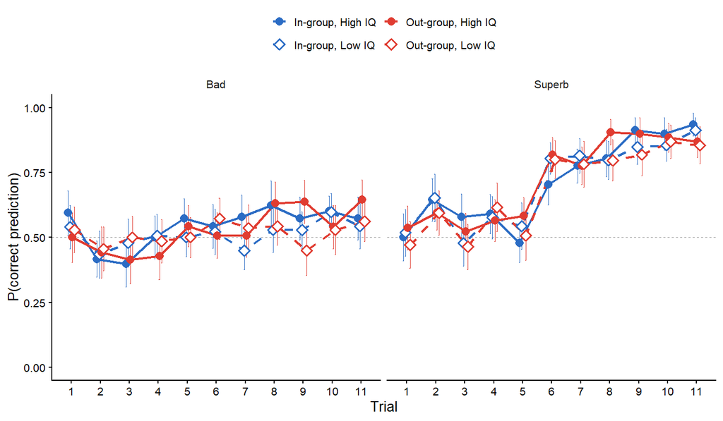

```r
fig_prediction_condition_curves_combined <- ggplot(prediction_condition_curve_summary,
                                        aes(x = trial, y = mean, colour = condition, linetype = condition, shape = condition)) +
  geom_hline(yintercept = chance_level, linetype = "dashed", colour = "grey60", linewidth = 0.3) +
  geom_errorbar(aes(ymin = ci_low, ymax = ci_high), width = 0.15, linewidth = 0.35, linetype = "solid",
                position = position_dodge(width = 0.3), show.legend = FALSE) +
  geom_line(linewidth = 0.8, position = position_dodge(width = 0.3)) +
  geom_point(size = 2.2, stroke = 1, fill = "white", position = position_dodge(width = 0.3)) +
  scale_colour_manual(values = setNames(unname(colour_grouping[c("in", "in", "out", "out")]), condition_levels), name = NULL) +
  scale_linetype_manual(values = setNames(c("solid", "dashed", "solid", "dashed"), condition_levels), name = NULL) +
  scale_shape_manual(values = setNames(c(16, 23, 16, 23), condition_levels), name = NULL) +
  scale_x_continuous(breaks = sort(unique(prediction_condition_curve_summary$trial))) +
  facet_wrap(~ perf, labeller = labeller(perf = label_perf)) +
  coord_cartesian(ylim = c(0, 1)) +
  labs(x = "Trial", y = "P(correct prediction)") +
  guides(colour = guide_legend(nrow = 2), linetype = guide_legend(nrow = 2), shape = guide_legend(nrow = 2))

fig_prediction_condition_curves_combined
```

```r
ggsave(file.path(figure_dir, "prediction_condition_curves_combined.png"), plot = fig_prediction_condition_curves_combined,
       width = 7.2, height = 4.2, units = "in", dpi = 300, bg = "white")
```

# 12. Imitation in the first trial and first five trials

Imitation means choosing the same option as the demonstrator. Trial 1 is raw trial 0; trials 1–5 are raw trials 0–4. These choices follow observed outcomes, including on trial 1.

## 12.1 First-trial imitation

```r
first_trial_data <- trial_data %>%
  filter(trial_num == 0)

first_trial_imitation_model <- glmer(
  imitated ~ grouping * iq * perf + (1 | participant),
  family = "binomial", data = first_trial_data,
  contrasts = list(grouping = "contr.sum", iq = "contr.sum", perf = "contr.sum"),
  control = glmerControl(optimizer = "bobyqa", optCtrl = list(maxfun = 200000)))

summary(first_trial_imitation_model)
```

```
## Generalized linear mixed model fit by maximum likelihood (Laplace
##   Approximation) [glmerMod]
##  Family: binomial  ( logit )
## Formula: imitated ~ grouping * iq * perf + (1 | participant)
##    Data: first_trial_data
## Control: glmerControl(optimizer = "bobyqa", optCtrl = list(maxfun = 2e+05))
##
##       AIC       BIC    logLik -2*log(L)  df.resid
##    1514.7    1559.6    -748.3    1496.7      1076
##
## Scaled residuals:
##     Min      1Q  Median      3Q     Max
## -1.1498 -1.0150  0.8697  0.9487  1.0690
##
## Random effects:
##  Groups      Name        Variance Std.Dev.
##  participant (Intercept) 0        0
## Number of obs: 1085, groups:  participant, 46
##
## Fixed effects:
##                      Estimate Std. Error z value Pr(>|z|)
## (Intercept)          0.093772   0.060929   1.539    0.124
## grouping1           -0.005618   0.060929  -0.092    0.927
## iq1                  0.068812   0.060929   1.129    0.259
## perf1                0.034254   0.060929   0.562    0.574
## grouping1:iq1        0.100814   0.060929   1.655    0.098 .
## grouping1:perf1      0.002471   0.060929   0.041    0.968
## iq1:perf1           -0.042545   0.060929  -0.698    0.485
## grouping1:iq1:perf1  0.027211   0.060929   0.447    0.655
## ---
## Signif. codes:  0 '***' 0.001 '**' 0.01 '*' 0.05 '.' 0.1 ' ' 1
##
## Correlation of Fixed Effects:
##             (Intr) grpng1 iq1    perf1  grpng1:q1 grpng1:p1 iq1:p1
## grouping1    0.000
## iq1          0.003  0.000
## perf1       -0.007  0.003  0.000
## groupng1:q1  0.000  0.003  0.000  0.002
## grpng1:prf1  0.003 -0.007  0.002  0.000  0.000
## iq1:perf1    0.000  0.002 -0.007  0.003  0.003     0.000
## grpng1:q1:1  0.002  0.000  0.003  0.000 -0.007     0.003     0.000
## optimizer (bobyqa) convergence code: 0 (OK)
## boundary (singular) fit: see help('isSingular')
```

```r
isSingular(first_trial_imitation_model)
```

```
## [1] TRUE
```

```r
joint_tests(first_trial_imitation_model)
```

```
##  model term       df1 df2 F.ratio Chisq p.value
##  grouping           1 Inf   0.009 0.009  0.9265
##  iq                 1 Inf   1.275 1.275  0.2587
##  perf               1 Inf   0.316 0.316  0.5740
##  grouping:iq        1 Inf   2.738 2.738  0.0980
##  grouping:perf      1 Inf   0.002 0.002  0.9677
##  iq:perf            1 Inf   0.488 0.488  0.4850
##  grouping:iq:perf   1 Inf   0.199 0.199  0.6552
```

```r
first_trial_imitation_emm <- emmeans(first_trial_imitation_model, ~ grouping * iq | perf)
summary(first_trial_imitation_emm, type = "response")
```

```
## perf = bad:
##  grouping iq    prob     SE  df asymp.LCL asymp.UCL
##  in       high 0.569 0.0423 Inf     0.485     0.650
##  out      high 0.507 0.0429 Inf     0.424     0.590
##  in       low  0.493 0.0429 Inf     0.410     0.576
##  out      low  0.558 0.0423 Inf     0.474     0.639
##
## perf = superb:
##  grouping iq    prob     SE  df asymp.LCL asymp.UCL
##  in       high 0.559 0.0426 Inf     0.474     0.640
##  out      high 0.526 0.0433 Inf     0.442     0.610
##  in       low  0.467 0.0429 Inf     0.384     0.551
##  out      low  0.507 0.0432 Inf     0.423     0.591
##
## Confidence level used: 0.95
## Intervals are back-transformed from the logit scale
```

```r
summary(pairs(first_trial_imitation_emm, adjust = "tukey"),
        type = "response", infer = c(TRUE, TRUE))
```

```
## perf = bad:
##  contrast           odds.ratio    SE  df asymp.LCL asymp.UCL null z.ratio
##  in high / out high      1.284 0.312 Inf     0.687      2.40    1   1.027
##  in high / in low        1.361 0.331 Inf     0.729      2.54    1   1.268
##  in high / out low       1.047 0.255 Inf     0.561      1.96    1   0.190
##  out high / in low       1.061 0.257 Inf     0.569      1.98    1   0.243
##  out high / out low      0.816 0.198 Inf     0.438      1.52    1  -0.839
##  in low / out low        0.769 0.187 Inf     0.413      1.43    1  -1.082
##  p.value
##   0.7338
##   0.5831
##   0.9976
##   0.9950
##   0.8357
##   0.7006
##
## perf = superb:
##  contrast           odds.ratio    SE  df asymp.LCL asymp.UCL null z.ratio
##  in high / out high      1.140 0.279 Inf     0.608      2.14    1   0.535
##  in high / in low        1.448 0.353 Inf     0.773      2.71    1   1.515
##  in high / out low       1.229 0.300 Inf     0.656      2.30    1   0.845
##  out high / in low       1.270 0.311 Inf     0.677      2.38    1   0.976
##  out high / out low      1.078 0.264 Inf     0.575      2.02    1   0.308
##  in low / out low        0.849 0.207 Inf     0.454      1.59    1  -0.669
##  p.value
##   0.9505
##   0.4282
##   0.8327
##   0.7632
##   0.9899
##   0.9087
##
## Confidence level used: 0.95
## Conf-level adjustment: tukey method for comparing a family of 4 estimates
## Intervals are back-transformed from the log odds ratio scale
## P value adjustment: tukey method for comparing a family of 4 estimates
## Tests are performed on the log odds ratio scale
```

## 12.2 Imitation over the first five trials

Trial is centred at trial 3 within this window. Condition contrasts are evaluated at trial 3.

```r
first_five_trial_data <- trial_data %>%
  filter(trial_num %in% 0:4) %>%
  mutate(early_trial_c = trial_num - 2)

first_five_imitation_model <- glmer(
  imitated ~ early_trial_c * grouping * iq * perf +
    (1 + early_trial_c | participant) + (1 | demo_img),
  family = "binomial", data = first_five_trial_data,
  contrasts = list(grouping = "contr.sum", iq = "contr.sum", perf = "contr.sum"),
  control = glmerControl(optimizer = "bobyqa", optCtrl = list(maxfun = 200000)))

summary(first_five_imitation_model)
```

```
## Generalized linear mixed model fit by maximum likelihood (Laplace
##   Approximation) [glmerMod]
##  Family: binomial  ( logit )
## Formula:
## imitated ~ early_trial_c * grouping * iq * perf + (1 + early_trial_c |
##     participant) + (1 | demo_img)
##    Data: first_five_trial_data
## Control: glmerControl(optimizer = "bobyqa", optCtrl = list(maxfun = 2e+05))
##
##       AIC       BIC    logLik -2*log(L)  df.resid
##    7450.0    7582.1   -3705.0    7410.0      5448
##
## Scaled residuals:
##     Min      1Q  Median      3Q     Max
## -2.2113 -1.0717  0.7405  0.8874  1.2563
##
## Random effects:
##  Groups      Name          Variance  Std.Dev. Corr
##  demo_img    (Intercept)   0.0073582 0.08578
##  participant (Intercept)   0.0685275 0.26178
##              early_trial_c 0.0004808 0.02193  -1.00
## Number of obs: 5468, groups:  demo_img, 48; participant, 46
##
## Fixed effects:
##                                    Estimate Std. Error z value Pr(>|z|)
## (Intercept)                        0.265509   0.049114   5.406 6.45e-08 ***
## early_trial_c                      0.061397   0.019889   3.087  0.00202 **
## grouping1                         -0.042732   0.027743  -1.540  0.12349
## iq1                                0.012480   0.027723   0.450  0.65259
## perf1                             -0.140364   0.027789  -5.051 4.39e-07 ***
## early_trial_c:grouping1           -0.017847   0.019577  -0.912  0.36196
## early_trial_c:iq1                 -0.010907   0.019576  -0.557  0.57739
## grouping1:iq1                      0.023263   0.027756   0.838  0.40197
## early_trial_c:perf1               -0.006467   0.019581  -0.330  0.74118
## grouping1:perf1                   -0.015944   0.027729  -0.575  0.56528
## iq1:perf1                          0.010123   0.027721   0.365  0.71497
## early_trial_c:grouping1:iq1       -0.023538   0.019576  -1.202  0.22921
## early_trial_c:grouping1:perf1     -0.016509   0.019576  -0.843  0.39904
## early_trial_c:iq1:perf1            0.036216   0.019576   1.850  0.06432 .
## grouping1:iq1:perf1               -0.013347   0.027734  -0.481  0.63033
## early_trial_c:grouping1:iq1:perf1 -0.003547   0.019576  -0.181  0.85620
## ---
## Signif. codes:  0 '***' 0.001 '**' 0.01 '*' 0.05 '.' 0.1 ' ' 1
```

```
## optimizer (bobyqa) convergence code: 0 (OK)
## boundary (singular) fit: see help('isSingular')
```

```r
isSingular(first_five_imitation_model)
```

```
## [1] TRUE
```

```r
joint_tests(first_five_imitation_model, at = list(early_trial_c = c(-1, 1)))
```

```
##  model term                     df1 df2 F.ratio  Chisq p.value
##  early_trial_c                    1 Inf   9.530  9.530  0.0020
##  grouping                         1 Inf   2.372  2.372  0.1235
##  iq                               1 Inf   0.203  0.203  0.6526
##  perf                             1 Inf  25.513 25.513 <0.0001
##  early_trial_c:grouping           1 Inf   0.831  0.831  0.3620
##  early_trial_c:iq                 1 Inf   0.310  0.310  0.5774
##  early_trial_c:perf               1 Inf   0.109  0.109  0.7412
##  grouping:iq                      1 Inf   0.702  0.702  0.4020
##  grouping:perf                    1 Inf   0.331  0.331  0.5653
##  iq:perf                          1 Inf   0.133  0.133  0.7150
##  early_trial_c:grouping:iq        1 Inf   1.446  1.446  0.2292
##  early_trial_c:grouping:perf      1 Inf   0.711  0.711  0.3990
##  early_trial_c:iq:perf            1 Inf   3.422  3.422  0.0643
##  grouping:iq:perf                 1 Inf   0.232  0.232  0.6303
##  early_trial_c:grouping:iq:perf   1 Inf   0.033  0.033  0.8562
```

```r
first_five_imitation_emm <- emmeans(first_five_imitation_model, ~ grouping * iq | perf,
                                   at = list(early_trial_c = 0))
summary(first_five_imitation_emm, type = "response")
```

```
## perf = bad:
##  grouping iq    prob     SE  df asymp.LCL asymp.UCL
##  in       high 0.525 0.0218 Inf     0.482     0.567
##  out      high 0.549 0.0218 Inf     0.506     0.591
##  in       low  0.508 0.0219 Inf     0.466     0.551
##  out      low  0.543 0.0217 Inf     0.500     0.585
##
## perf = superb:
##  grouping iq    prob     SE  df asymp.LCL asymp.UCL
##  in       high 0.603 0.0213 Inf     0.561     0.644
##  out      high 0.598 0.0213 Inf     0.556     0.639
##  in       low  0.584 0.0215 Inf     0.542     0.626
##  out      low  0.615 0.0212 Inf     0.572     0.655
##
## Confidence level used: 0.95
## Intervals are back-transformed from the logit scale
```

```r
summary(pairs(first_five_imitation_emm, adjust = "tukey"),
        type = "response", infer = c(TRUE, TRUE))
```

```
## perf = bad:
##  contrast           odds.ratio     SE  df asymp.LCL asymp.UCL null z.ratio
##  in high / out high      0.907 0.0998 Inf     0.684      1.20    1  -0.886
##  in high / in low        1.067 0.1170 Inf     0.805      1.41    1   0.593
##  in high / out low       0.930 0.1020 Inf     0.702      1.23    1  -0.658
##  out high / in low       1.177 0.1300 Inf     0.887      1.56    1   1.476
##  out high / out low      1.026 0.1130 Inf     0.773      1.36    1   0.231
##  in low / out low        0.872 0.0957 Inf     0.658      1.16    1  -1.250
##  p.value
##   0.8120
##   0.9343
##   0.9127
##   0.4521
##   0.9957
##   0.5951
##
## perf = superb:
##  contrast           odds.ratio     SE  df asymp.LCL asymp.UCL null z.ratio
##  in high / out high      1.020 0.1140 Inf     0.765      1.36    1   0.176
##  in high / in low        1.081 0.1210 Inf     0.812      1.44    1   0.698
##  in high / out low       0.952 0.1070 Inf     0.714      1.27    1  -0.435
##  out high / in low       1.060 0.1180 Inf     0.796      1.41    1   0.522
##  out high / out low      0.934 0.1050 Inf     0.700      1.25    1  -0.610
##  in low / out low        0.881 0.0988 Inf     0.660      1.17    1  -1.131
##  p.value
##   0.9981
##   0.8978
##   0.9724
##   0.9538
##   0.9290
##   0.6704
##
## Confidence level used: 0.95
## Conf-level adjustment: tukey method for comparing a family of 4 estimates
## Intervals are back-transformed from the log odds ratio scale
## P value adjustment: tukey method for comparing a family of 4 estimates
## Tests are performed on the log odds ratio scale
```

```r
first_five_imitation_slopes <- emtrends(first_five_imitation_model, ~ grouping * iq | perf,
                                       var = "early_trial_c")
summary(first_five_imitation_slopes, infer = c(TRUE, TRUE))
```

```
## perf = bad:
##  grouping iq   early_trial_c.trend     SE  df asymp.LCL asymp.UCL z.ratio
##  in       high            0.018796 0.0547 Inf   -0.0884     0.126   0.344
##  out      high            0.141680 0.0553 Inf    0.0332     0.250   2.560
##  in       low             0.022350 0.0548 Inf   -0.0850     0.130   0.408
##  out      low             0.036892 0.0548 Inf   -0.0706     0.144   0.673
##  p.value
##   0.7312
##   0.0105
##   0.6832
##   0.5010
##
## perf = superb:
##  grouping iq   early_trial_c.trend     SE  df asymp.LCL asymp.UCL z.ratio
##  in       high           -0.000587 0.0559 Inf   -0.1101     0.109  -0.011
##  out      high            0.042069 0.0560 Inf   -0.0676     0.152   0.752
##  in       low             0.133640 0.0559 Inf    0.0241     0.243   2.392
##  out      low             0.096334 0.0565 Inf   -0.0144     0.207   1.705
##  p.value
##   0.9916
##   0.4522
##   0.0168
##   0.0882
##
## Confidence level used: 0.95
```

## 12.3 Imitation figures

Participant means and 95% CIs are shown separately for each window and performance level.

```r
imitation_participant <- bind_rows(
  first_trial_data %>% mutate(window = "First trial"),
  first_five_trial_data %>% mutate(window = "First five trials")) %>%
  group_by(participant, window, grouping, iq, perf) %>%
  summarise(imitation_rate = mean(imitated, na.rm = TRUE),
            n_responses = sum(!is.na(imitated)), .groups = "drop") %>%
  filter(n_responses > 0) %>%
  mutate(window = factor(window, levels = c("First trial", "First five trials")))

imitation_summary <- imitation_participant %>%
  group_by(window, grouping, iq, perf) %>%
  summarise(n = n(), mean = mean(imitation_rate), sd = sd(imitation_rate), .groups = "drop") %>%
  mutate(ci_low = mean - qt(0.975, n - 1) * sd / sqrt(n),
         ci_high = mean + qt(0.975, n - 1) * sd / sqrt(n))

imitation_summary %>% mutate(across(where(is.numeric), ~ round(.x, 3)))
```

```
## # A tibble: 16 × 9
##    window            grouping iq    perf       n  mean    sd ci_low ci_high
##    <fct>             <fct>    <fct> <fct>  <dbl> <dbl> <dbl>  <dbl>   <dbl>
##  1 First trial       in       high  bad       46 0.565 0.336  0.465   0.665
##  2 First trial       in       high  superb    46 0.558 0.321  0.463   0.653
##  3 First trial       in       low   bad       46 0.489 0.303  0.399   0.579
##  4 First trial       in       low   superb    46 0.471 0.326  0.374   0.568
##  5 First trial       out      high  bad       46 0.504 0.311  0.411   0.596
##  6 First trial       out      high  superb    45 0.526 0.277  0.443   0.609
##  7 First trial       out      low   bad       46 0.558 0.299  0.469   0.647
##  8 First trial       out      low   superb    46 0.504 0.257  0.427   0.58
##  9 First five trials in       high  bad       46 0.523 0.143  0.481   0.565
## 10 First five trials in       high  superb    46 0.601 0.096  0.572   0.63
## 11 First five trials in       low   bad       46 0.507 0.131  0.468   0.546
## 12 First five trials in       low   superb    46 0.583 0.115  0.548   0.617
## 13 First five trials out      high  bad       46 0.548 0.143  0.505   0.59
## 14 First five trials out      high  superb    46 0.597 0.117  0.562   0.632
## 15 First five trials out      low   bad       46 0.542 0.145  0.499   0.585
## 16 First five trials out      low   superb    46 0.612 0.103  0.582   0.643
```

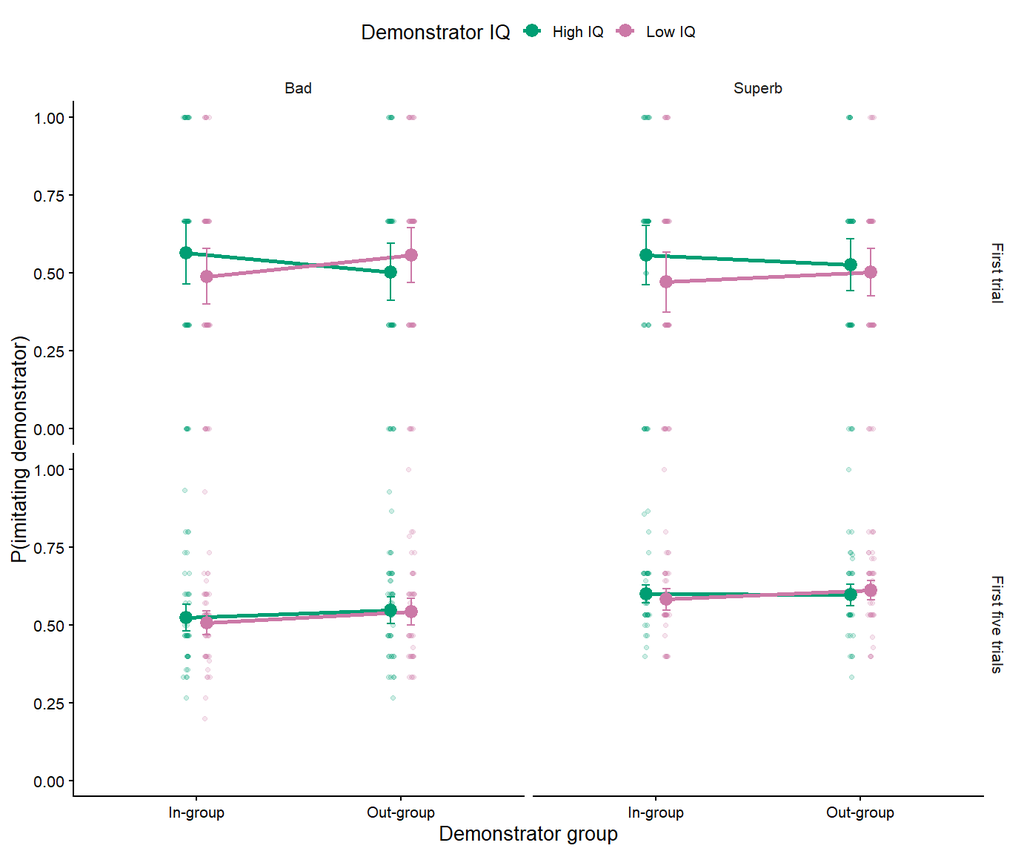

```r
fig_imitation <- ggplot(imitation_participant,
                        aes(x = grouping, y = imitation_rate, colour = iq, group = iq)) +
  geom_point(position = position_jitterdodge(jitter.width = 0.06, dodge.width = 0.2, seed = 1),
             alpha = 0.20, size = 1) +
  geom_line(data = imitation_summary, aes(y = mean), linewidth = 0.9,
            position = position_dodge(width = 0.2)) +
  geom_errorbar(data = imitation_summary, aes(y = mean, ymin = ci_low, ymax = ci_high),
                width = 0.08, position = position_dodge(width = 0.2)) +
  geom_point(data = imitation_summary, aes(y = mean), size = 2.8,
             position = position_dodge(width = 0.2)) +
  facet_grid(window ~ perf, labeller = labeller(perf = label_perf)) +
  scale_x_discrete(labels = label_grouping) +
  scale_colour_manual(values = colour_iq, labels = label_iq, name = "Demonstrator IQ") +
  coord_cartesian(ylim = c(0, 1)) +
  labs(x = "Demonstrator group", y = "P(imitating demonstrator)")

fig_imitation
```

```r
ggsave(file.path(figure_dir, "imitation.png"), plot = fig_imitation,
       width = 7.2, height = 6, units = "in", dpi = 300, bg = "white")
```

# 13. Response-time descriptives

```r
response_time_participant <- bind_rows(
  trial_data %>% transmute(participant, grouping, iq, perf,
                           response = "Choice", rt = choice_rt),
  prediction_trial_data %>% transmute(participant, grouping, iq, perf,
                                      response = "Prediction", rt = pred_rt)) %>%
  filter(!is.na(rt)) %>%
  group_by(participant, response, grouping, iq, perf) %>%
  summarise(mean_rt = mean(rt), prop_fast = mean(rt < 200),
            prop_slow = mean(rt > 10000), .groups = "drop")

response_time_summary <- response_time_participant %>%
  group_by(response, grouping, iq, perf) %>%
  summarise(n = n(), mean = mean(mean_rt), sem = sd(mean_rt) / sqrt(n()),
            prop_fast = mean(prop_fast), prop_slow = mean(prop_slow), .groups = "drop")

response_time_summary %>% mutate(across(where(is.numeric), ~ round(.x, 3)))
```

```
## # A tibble: 16 × 9
##    response   grouping iq    perf       n  mean   sem prop_fast prop_slow
##    <chr>      <fct>    <fct> <fct>  <dbl> <dbl> <dbl>     <dbl>     <dbl>
##  1 Choice     in       high  bad       46  656.  25.8     0.001         0
##  2 Choice     in       high  superb    46  655.  23.9     0.003         0
##  3 Choice     in       low   bad       46  652.  23.2     0.001         0
##  4 Choice     in       low   superb    46  645.  24.8     0             0
##  5 Choice     out      high  bad       46  667.  25.2     0.001         0
##  6 Choice     out      high  superb    46  640.  21.7     0             0
##  7 Choice     out      low   bad       46  664.  24.8     0.003         0
##  8 Choice     out      low   superb    46  644.  23.6     0.001         0
##  9 Prediction in       high  bad       46  763.  29.7     0.001         0
## 10 Prediction in       high  superb    46  736.  28.6     0.002         0
## 11 Prediction in       low   bad       46  777.  28.6     0.002         0
## 12 Prediction in       low   superb    46  761.  28.6     0             0
## 13 Prediction out      high  bad       46  789.  31.9     0             0
## 14 Prediction out      high  superb    46  758.  28.5     0.001         0
## 15 Prediction out      low   bad       46  805.  32.3     0.001         0
## 16 Prediction out      low   superb    46  757.  29.6     0.002         0
```

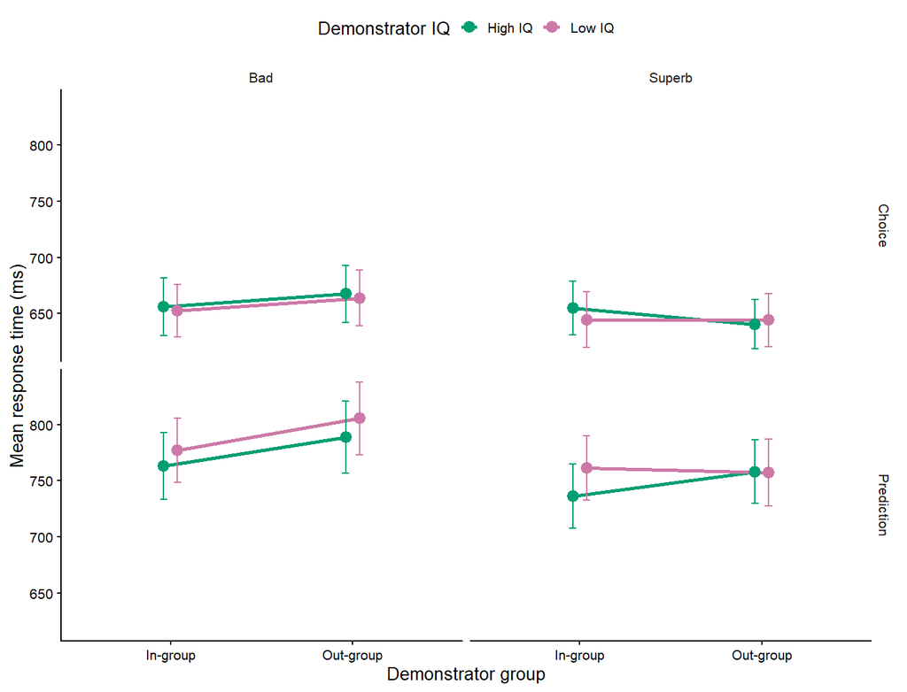

```r
fig_response_time <- ggplot(response_time_summary,
                            aes(x = grouping, y = mean, colour = iq, group = iq)) +
  geom_line(linewidth = 0.9, position = position_dodge(width = 0.15)) +
  geom_errorbar(aes(ymin = mean - sem, ymax = mean + sem),
                width = 0.08, position = position_dodge(width = 0.15)) +
  geom_point(size = 2.8, position = position_dodge(width = 0.15)) +
  facet_grid(response ~ perf, labeller = labeller(perf = label_perf)) +
  scale_x_discrete(labels = label_grouping) +
  scale_colour_manual(values = colour_iq, labels = label_iq, name = "Demonstrator IQ") +
  labs(x = "Demonstrator group", y = "Mean response time (ms)")

fig_response_time
```

```r
ggsave(file.path(figure_dir, "response_time.png"), plot = fig_response_time,
       width = 7.2, height = 5.5, units = "in", dpi = 300, bg = "white")
```